# PSC article analysis Q1 - NORWAY

##### pre_ltx vs post_ltx

```r
group <- c("pre_ltx","post_ltx")
comparison_name <- paste0(group[1], " vs ",group[2])
```

**linDA**

```r
# prepare the data
linda_data <- binomial_prep(ileum_phylum_tab,
                            ileum_phylum_taxa_tab,
                            ileum_metadata,
                            group, usage="linDA")
```

```
## Removing 1 ASV(s)
```

```r
filt_ileum_uni_data <- linda_data[[1]]
filt_ileum_uni_taxa <- linda_data[[2]]
filt_ileum_uni_metadata <- linda_data[[3]]

# fit the model
linda.obj <- linda(filt_ileum_uni_data,
                   filt_ileum_uni_metadata,
                   formula = '~ Group')
```

```
## 0  features are filtered!
## The filtered data has  82  samples and  11  features will be tested!
## Pseudo-count approach is used.
## Fit linear models ...
## Completed.
```

```r
linda.output <- linda.obj$output
linda.output <- linda_renaming(linda.output, group)

# save the results
group1 <- paste0(group[1], " vs ","Group",group[2])

for (grp in c(group1)){
  raw_linda_results_phylum[[segment]][[grp]] <-
    rawlinda.df(linda.output,
                grp,
                filt_ileum_uni_data,
                filt_ileum_uni_taxa)

  linda_results_phylum[[segment]][[grp]] <-
    linda.df(linda.output,
             grp,
             filt_ileum_uni_data,
             filt_ileum_uni_taxa)
}
```

```r
# volcano plot
volcano_1 <- volcano_plot_linda(linda.output,
                                group1,
                                taxa_table = filt_ileum_uni_taxa) +
            ggtitle(comparison_name)
```

```
## Using Phylum for naming
```

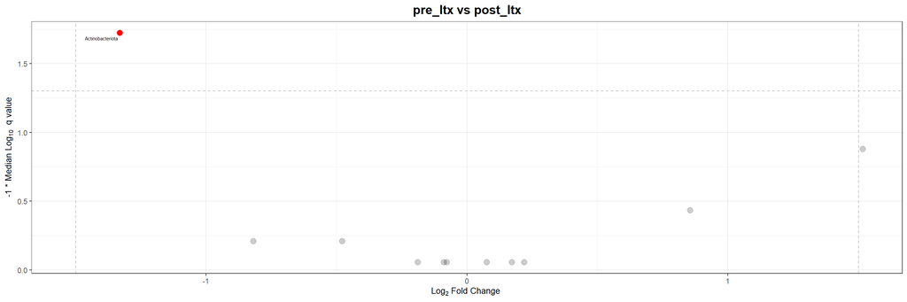

```r
volcano <- ggarrange(volcano_1)
volcano
```

**MaAsLin2**

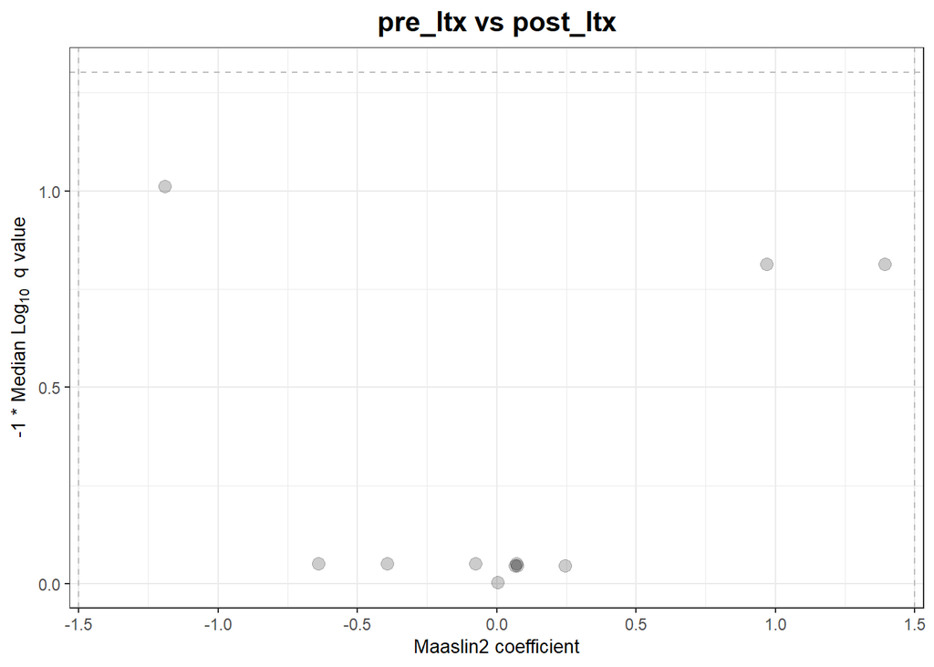

```r
volcano1 <- volcano_plot_maaslin(fit_data,filt_ileum_uni_taxa) +
            ggtitle(comparison_name)

volcano <- ggarrange(volcano1)
volcano
```

**Group - Intersection**

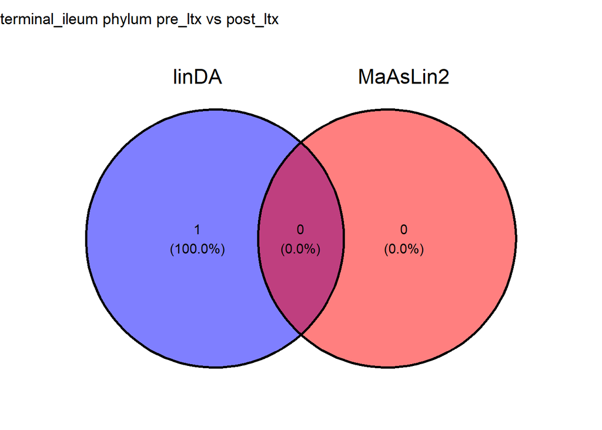

```r
intersection_results <- group_intersection(group, list_intersections, list_venns,
                                           linda.output, fit_data,
                                           raw_linda_results_phylum,
                                           segment = segment,
                                           level=level)

list_intersections <- intersection_results[[1]]
list_venns <- intersection_results[[2]]
venn <- intersection_results[[3]]

# show the results
venn
```

**Basic statistics**

```r
uni_df <-  merge(basic_univariate_statistics(linda_data,group),
                 raw_linda_results_phylum[[segment]][[group1]],
                 by="SeqID",all=TRUE)
```

```
## [1] "pre_ltx"
## [1] "post_ltx"
## [1] "pre_ltx"
## [1] "post_ltx"
```

```r
uni_df[["final_sig"]] <- uni_df$SeqID %in% list_intersections[[paste(segment,level,comparison_name)]][["SeqID"]]
uni_statistics[[segment]][[paste(level,comparison_name)]] <- uni_df

# for comparison
new_name <- paste(level,comparison_name)
addWorksheet(supplements_wb, sheetName = new_name)
writeData(supplements_wb, sheet = new_name, uni_df, rowNames=FALSE)
```

##### post_ltx vs healthy

```r
group <- c("healthy","post_ltx")
comparison_name <- paste0(group[1], " vs ",group[2])
```

**linDA**

```r
# prepare the data
linda_data <- binomial_prep(ileum_phylum_tab,
                            ileum_phylum_taxa_tab,
                            ileum_metadata,
                            group, usage="linDA")
```

```
## Removing 2 ASV(s)
```

```r
filt_ileum_uni_data <- linda_data[[1]]
filt_ileum_uni_taxa <- linda_data[[2]]
filt_ileum_uni_metadata <- linda_data[[3]]

# fit the model
linda.obj <- linda(filt_ileum_uni_data,
                   filt_ileum_uni_metadata,
                   formula = '~ Group')
```

```
## 0  features are filtered!
## The filtered data has  72  samples and  11  features will be tested!
## Pseudo-count approach is used.
## Fit linear models ...
## Completed.
```

```r
linda.output <- linda.obj$output
linda.output <- linda_renaming(linda.output, group)

# save the results
group1 <- paste0(group[1], " vs ","Group",group[2])

for (grp in c(group1)){
  raw_linda_results_phylum[[segment]][[grp]] <-
    rawlinda.df(linda.output,
                grp,
                filt_ileum_uni_data,
                filt_ileum_uni_taxa)

  linda_results_phylum[[segment]][[grp]] <-
    linda.df(linda.output,
             grp,
             filt_ileum_uni_data,
             filt_ileum_uni_taxa)
}
```

```r
# volcano plot
volcano_1 <- volcano_plot_linda(linda.output,
                                group1,
                                taxa_table = filt_ileum_uni_taxa) +
            ggtitle(comparison_name)
```

```
## Using Phylum for naming
```

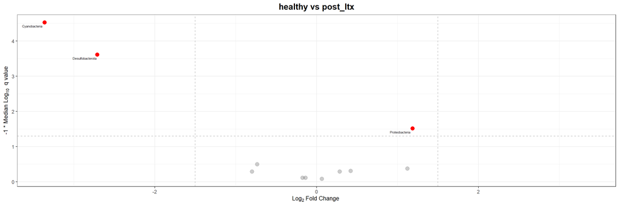

```r
volcano <- ggarrange(volcano_1)
volcano
```

**MaAsLin2**

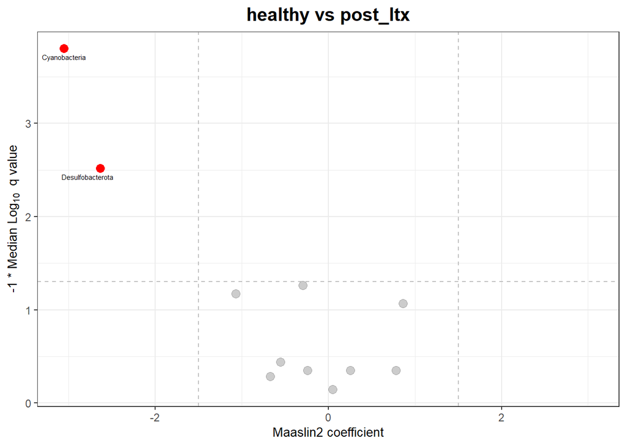

```r
volcano1 <- volcano_plot_maaslin(fit_data,filt_ileum_uni_taxa) +
            ggtitle(comparison_name)

volcano <- ggarrange(volcano1)
volcano
```

**Group - Intersection**

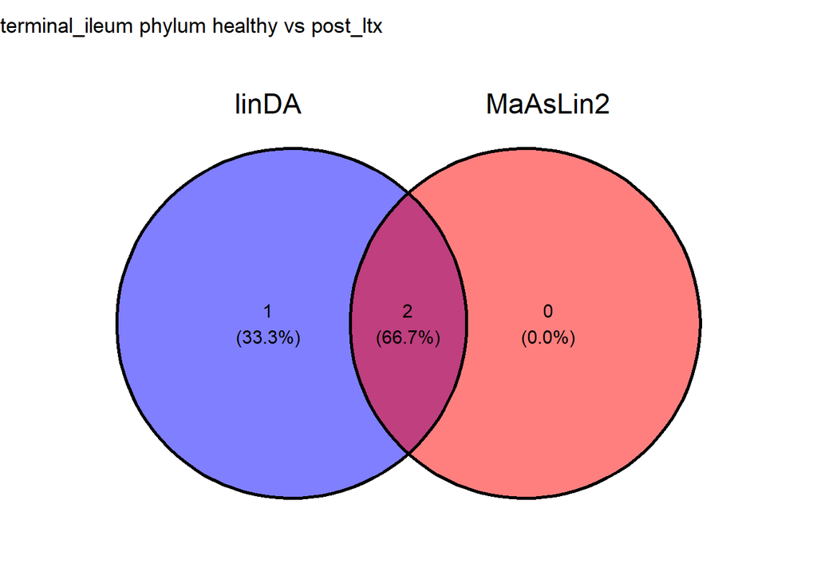

```r
intersection_results <- group_intersection(group, list_intersections, list_venns,
                                           linda.output, fit_data,
                                           raw_linda_results_phylum,
                                           segment = segment,
                                           level=level)

list_intersections <- intersection_results[[1]]
list_venns <- intersection_results[[2]]
venn <- intersection_results[[3]]

# show the results
venn
```

**Basic statistics**

```r
uni_df <-  merge(basic_univariate_statistics(linda_data,group),
                 raw_linda_results_phylum[[segment]][[group1]],
                 by="SeqID",all=TRUE)
```

```
## [1] "healthy"
## [1] "post_ltx"
## [1] "healthy"
## [1] "post_ltx"
```

```r
uni_df[["final_sig"]] <- uni_df$SeqID %in% list_intersections[[paste(segment,level,comparison_name)]][["SeqID"]]
uni_statistics[[segment]][[paste(level,comparison_name)]] <- uni_df

# for comparison
new_name <- paste(level,comparison_name)
addWorksheet(supplements_wb, sheetName = new_name)
writeData(supplements_wb, sheet = new_name, uni_df, rowNames=FALSE)
```

##### Visualization

Heatmap visualizing the linDA’s logFoldChange for taxa with p < 0.1.

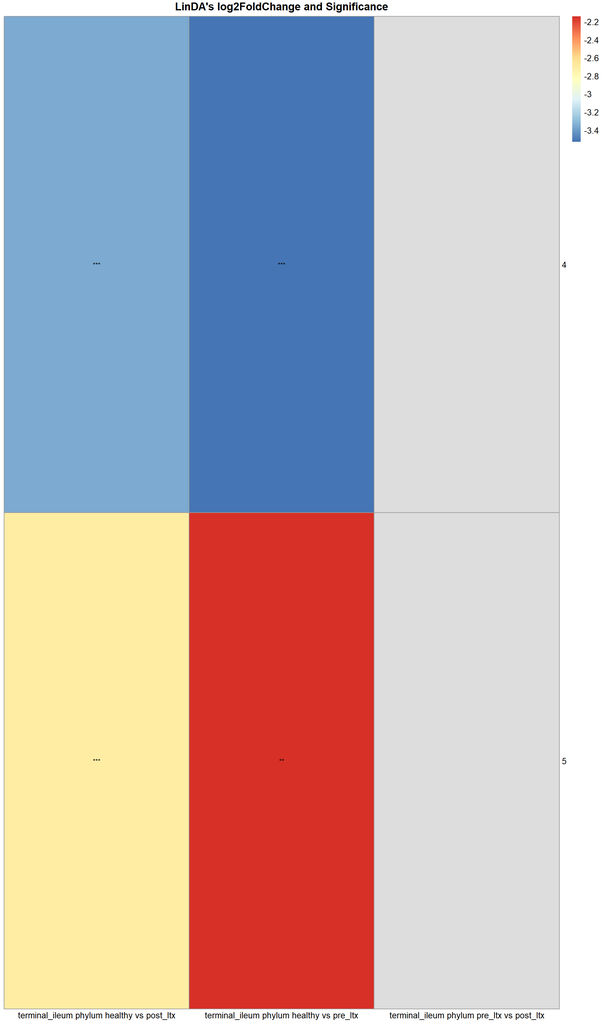

```r
list_heatmap <- list_intersections[grep(paste(segment,level),
                                  names(list_intersections),value=TRUE)]

p_heatmap_linda <- heatmap_linda(list_heatmap,ileum_taxa_tab)
p_heatmap_linda
```

Dot heatmap

```r
dotheatmap_linda <- dot_heatmap_linda(list_heatmap,
                                      uni_df,
                                      ileum_taxa_tab)
```

```
## min_clr -3.06026
## max_clr -0.1032386
## min_log -3.531459
## max_log -2.140763
```

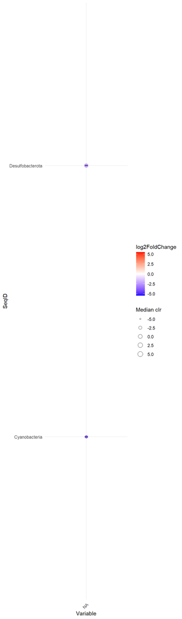

```r
dotheatmap_linda
```

##### PSC effect

**pre_LTx vs Healthy and Post_LTx vs Healthy intersection**

[figure not shown]

```r
A <- list_intersections[[paste(segment,level,"healthy vs pre_ltx")]]$SeqID
B <- list_intersections[[paste(segment,level,"healthy vs post_ltx")]]$SeqID
C <- intersect(A,B)

psc_effect[[paste(segment,level)]] <- list_intersections[[paste(segment,level, "healthy vs pre_ltx")]][list_intersections[[paste(segment,level, "healthy vs pre_ltx")]]$SeqID %in% C,]

# see the results
psc_effect[[paste(segment,level)]]
```

|  | SeqID | Taxonomy | log2FoldChange | p_value | padj |
| --- | --- | --- | --- | --- | --- |
| 4 | Cyanobacteria | k__Bacteria;p__Cyanobacteria | -3.531459 | 7.132789e-08 | 7.132789e-07 |
| 5 | Desulfobacterota | k__Bacteria;p__Desulfobacterota | -2.140763 | 8.634050e-04 | 4.317025e-03 |

#### Saving results

```r
# ALL DATA
saveWorkbook(supplements_wb,file.path(path,paste0("supplements_uni_analysis_wb_",segment,".xlsx")),overwrite = TRUE)

# PSC effect
write.xlsx(psc_effect,
          file.path(path,paste0("supplements_psc_effect_",segment,".xlsx")))

# SIGNIFICANT taxa
write.xlsx(list_intersections[grepl(segment,names(list_intersections))] %>%
            `names<-`(gsub(segment, "", names(
              list_intersections[grepl(segment,names(list_intersections))]))),
           file.path(path,paste0("supplements_significant_taxa_",segment,".xlsx")))
```

## Machine learning

```r
path = "../results/Q1_norway/models"
```

### ElasticNet

```r
model="enet"
```

#### ASV level

```r
level="ASV"
```

##### pre_ltx vs healthy

```r
group <- c("pre_ltx","healthy")
comparison_name <- paste0(group[1], " vs ",group[2])
```

```r
model_name <- paste(comparison_name,level,segment)

# prepare the data
filt_ileum_uni_data <- binomial_prep(ileum_asv_tab,
                                     ileum_taxa_tab,
                                     ileum_metadata,
                                     group, usage="ml_clr")
```

```
## Removing 532 ASV(s)
```

```
## Removing 83 ASV(s)
```

```r
# fit the model
enet_model <- glmnet_binomial(filt_ileum_uni_data,
                              sample_method = "atypboot",
                              outcome="Group",
                              N=10,
                              reuse=TRUE,
                              file=model_name,
                              Q="Q1_norway")

# ROC curve
roc_c <- roc_curve(enet_model, group)
# save the results
models_summ <- list()
models_cm <- list()
betas <- list()
roc_cs <- list()

models_summ[[model_name]] <- enet_model$model_summary
models_cm[[model_name]] <- enet_model$conf_matrices$original
roc_cs[[model_name]] <- enet_model$kfold_rocobjs
betas[[model_name]] <- as.matrix(enet_model$betas)

# see the results
enet_model$model_summary %>% t()
```

```
##                                       [,1]
## alpha                           0.20000000
## lambda                          0.07910989
## auc                             1.00000000
## auc_czech                              NaN
## auc_no                          1.00000000
## auc_optimism_corrected          0.93940116
## auc_optimism_corrected_CIL      0.90697421
## auc_optimism_corrected_CIU      0.96887255
## accuracy                        1.00000000
## accuracy_czech                         NaN
## accuracy_no                     1.00000000
## accuracy_optimism_corrected     0.85195830
## accuracy_optimism_corrected_CIL 0.77261494
## accuracy_optimism_corrected_CIU 0.91788462
```

```r
enet_model$conf_matrices
```

```
## $original
##     Predicted
## True  0  1
##    0 36  0
##    1  0 46
##
## $czech
## [1] NaN
##
## $no
##     Predicted
## True  0  1
##    0 36  0
##    1  0 46
```

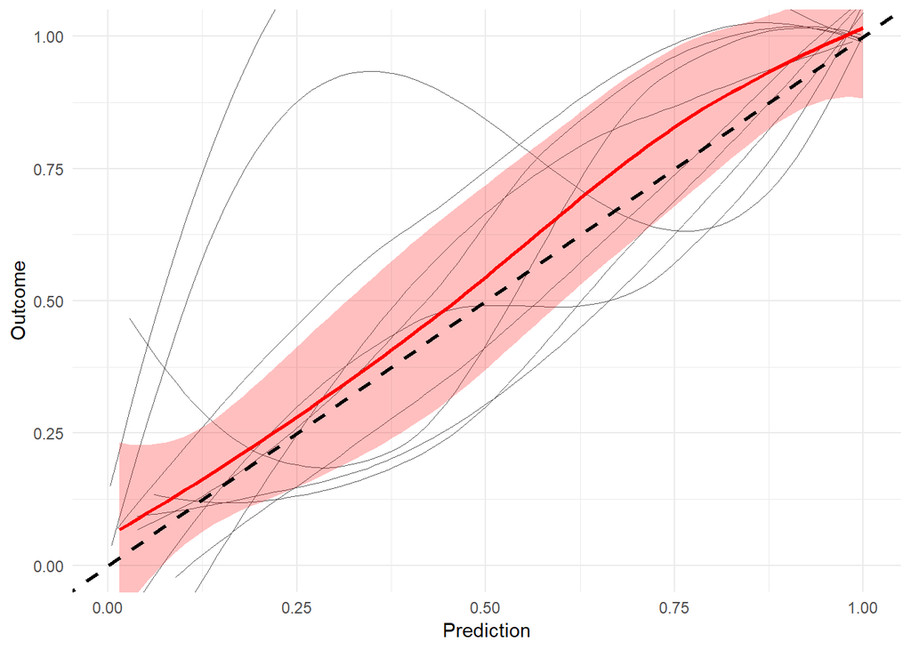

```r
enet_model$plot
```

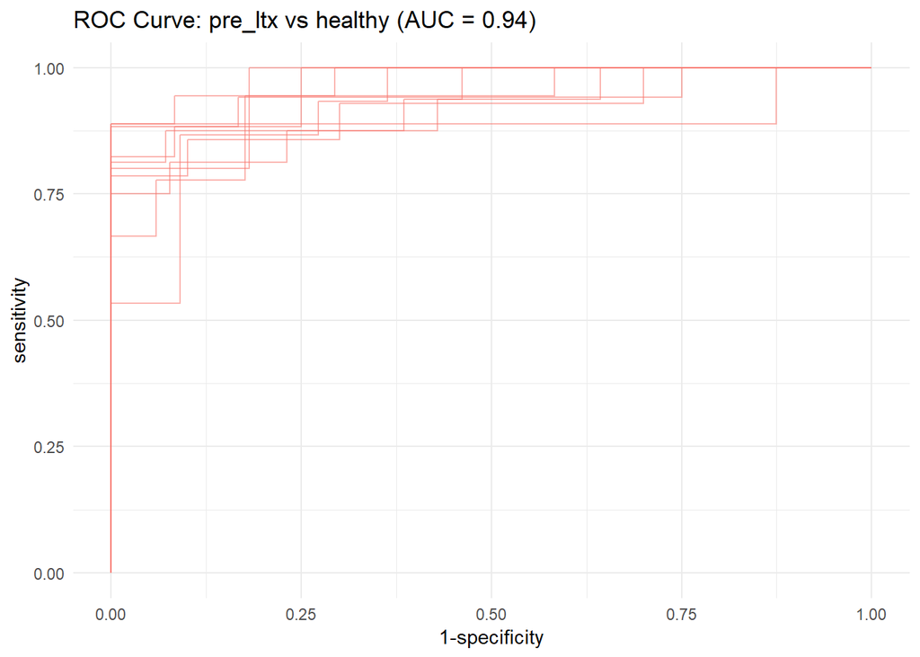

```r
roc_c
```

##### pre_ltx vs post_ltx

```r
group <- c("pre_ltx","post_ltx")
comparison_name <- paste0(group[1], " vs ",group[2])
```

```r
model_name <- paste(comparison_name,level,segment)

# prepare the data
filt_ileum_uni_data <- binomial_prep(ileum_asv_tab,
                                     ileum_taxa_tab,
                                     ileum_metadata,
                                     group,
                                     usage="ml_clr")
```

```
## Removing 798 ASV(s)
```

```
## Removing 48 ASV(s)
```

```r
# fit the model
enet_model <- glmnet_binomial(filt_ileum_uni_data,
                              sample_method = "atypboot",
                              outcome="Group",
                              N=10,
                              reuse=TRUE,
                              file=model_name,
                              Q="Q1_norway")

# ROC
roc_c <- roc_curve(enet_model, group)
# save the results
models_summ[[model_name]] <- enet_model$model_summary
models_cm[[model_name]] <- enet_model$conf_matrices$original
roc_cs[[model_name]] <- enet_model$kfold_rocobjs
betas[[model_name]] <- as.matrix(enet_model$betas)

# see the results
enet_model$model_summary %>% t()
```

```
##                                       [,1]
## alpha                           0.40000000
## lambda                          0.05275252
## auc                             1.00000000
## auc_czech                              NaN
## auc_no                          1.00000000
## auc_optimism_corrected          0.94864403
## auc_optimism_corrected_CIL      0.90596999
## auc_optimism_corrected_CIU      0.97906937
## accuracy                        1.00000000
## accuracy_czech                         NaN
## accuracy_no                     1.00000000
## accuracy_optimism_corrected     0.87262887
## accuracy_optimism_corrected_CIL 0.77354978
## accuracy_optimism_corrected_CIU 0.96640805
```

```r
enet_model$conf_matrices
```

```
## $original
##     Predicted
## True  0  1
##    0 36  0
##    1  0 46
##
## $czech
## [1] NaN
##
## $no
##     Predicted
## True  0  1
##    0 36  0
##    1  0 46
```

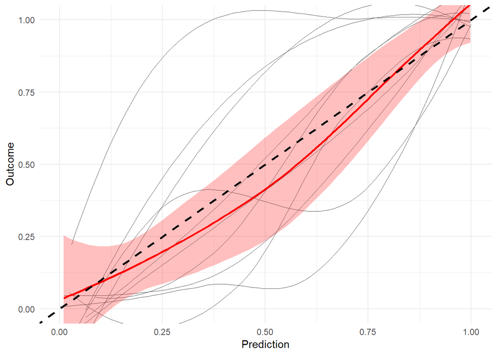

```r
enet_model$plot
```

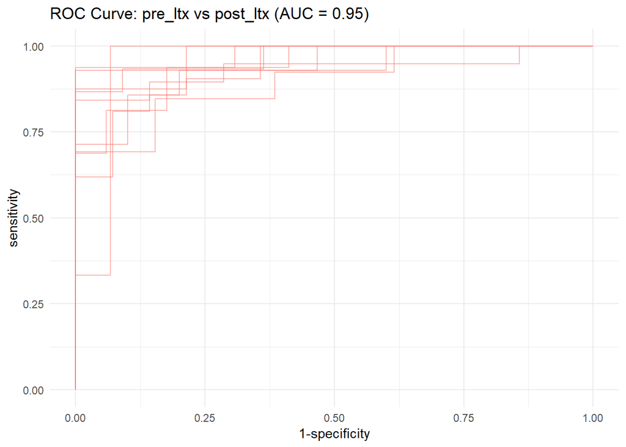

```r
roc_c
```

##### post_ltx vs healthy

```r
group <- c("post_ltx","healthy")
comparison_name <- paste0(group[1], " vs ",group[2])
```

```r
model_name <- paste(comparison_name,level,segment)

# prepare the data
filt_ileum_uni_data <- binomial_prep(ileum_asv_tab,
                                     ileum_taxa_tab,
                                     ileum_metadata,
                                     group,
                                     usage="ml_clr")
```

```
## Removing 582 ASV(s)
```

```
## Removing 94 ASV(s)
```

```r
# fit the model
enet_model <- glmnet_binomial(filt_ileum_uni_data,
                              sample_method = "atypboot",
                              outcome="Group",
                              N=10,
                              reuse=TRUE,
                              file=model_name,
                              Q="Q1_norway")

# ROC
roc_c <- roc_curve(enet_model, group)
# save the results
models_summ[[model_name]] <- enet_model$model_summary
models_cm[[model_name]] <- enet_model$conf_matrices$original
roc_cs[[model_name]] <- enet_model$kfold_rocobjs
betas[[model_name]] <- as.matrix(enet_model$betas)

# see the results
enet_model$model_summary %>% t()
```

```
##                                       [,1]
## alpha                           0.20000000
## lambda                          0.04385149
## auc                             1.00000000
## auc_czech                              NaN
## auc_no                          1.00000000
## auc_optimism_corrected          0.94057858
## auc_optimism_corrected_CIL      0.79925426
## auc_optimism_corrected_CIU      1.00000000
## accuracy                        1.00000000
## accuracy_czech                         NaN
## accuracy_no                     1.00000000
## accuracy_optimism_corrected     0.86393284
## accuracy_optimism_corrected_CIL 0.75621693
## accuracy_optimism_corrected_CIU 0.95775000
```

```r
enet_model$conf_matrices
```

```
## $original
##     Predicted
## True  0  1
##    0 36  0
##    1  0 36
##
## $czech
## [1] NaN
##
## $no
##     Predicted
## True  0  1
##    0 36  0
##    1  0 36
```

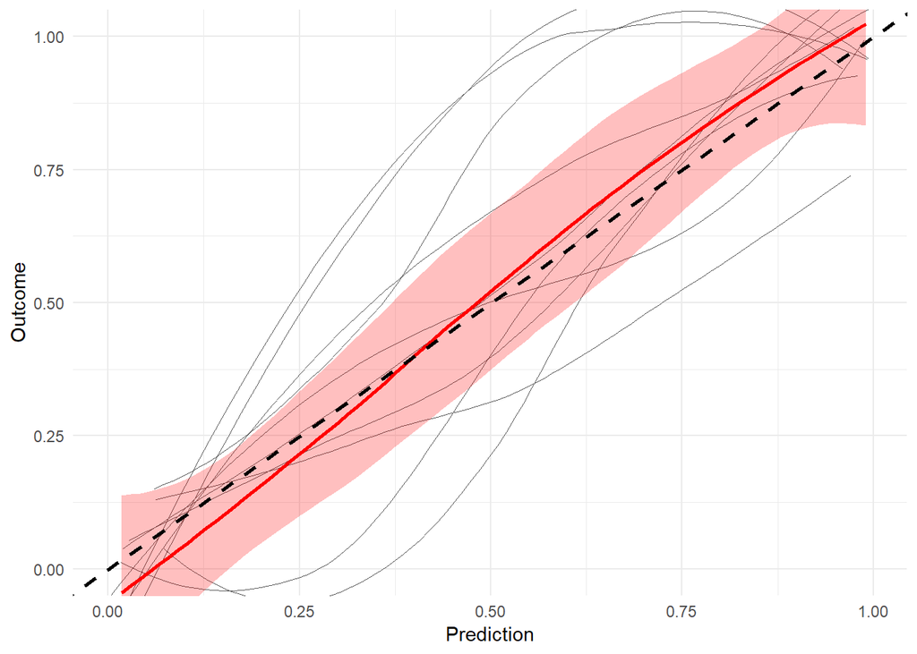

```r
enet_model$plot
```

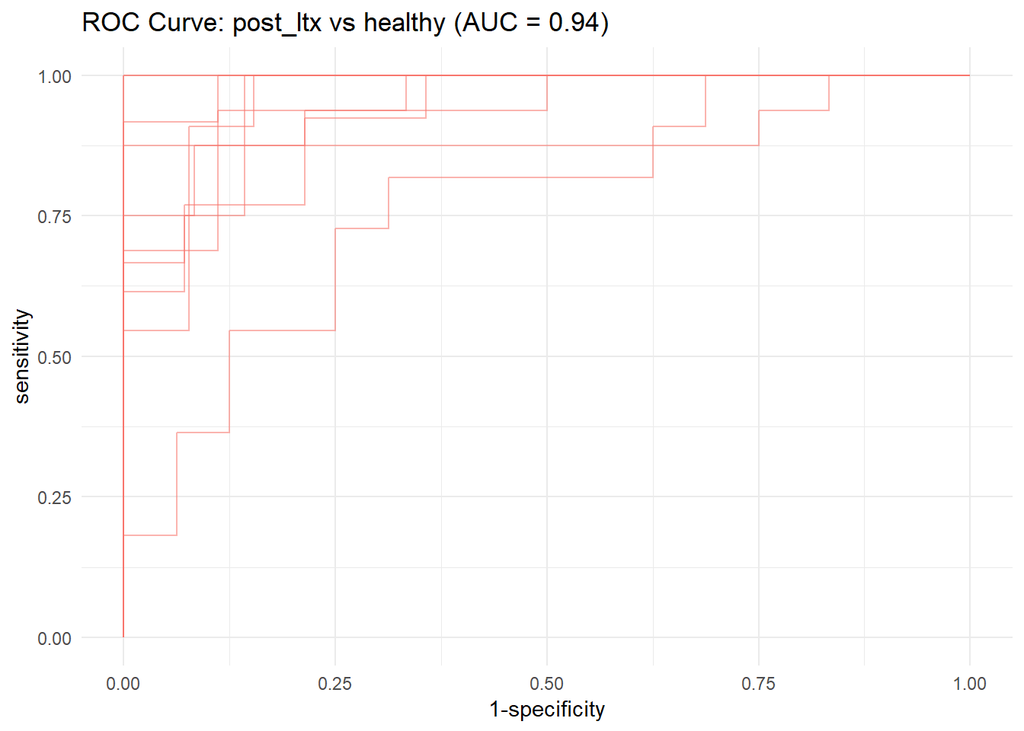

```r
roc_c
```

#### Genus level

```r
level="genus"
```

Aggregate taxa

```r
genus_data <- aggregate_taxa(ileum_asv_tab,
                             ileum_taxa_tab,
                             taxonomic_level = level)

ileum_genus_tab <- genus_data[[1]]
ileum_genus_taxa_tab <- genus_data[[2]]
```

##### pre_ltx vs healthy

```r
group <- c("pre_ltx","healthy")
comparison_name <- paste0(group[1], " vs ",group[2])
```

```r
model_name <- paste(comparison_name,level,segment)

# prepare the data
filt_ileum_uni_data <- binomial_prep(ileum_genus_tab,
                                     ileum_genus_taxa_tab,
                                     ileum_metadata,
                                     group,
                                     usage="ml_clr")
```

```
## Removing 37 ASV(s)
```

```
## Removing 6 ASV(s)
```

```r
# fit the model
enet_model <- glmnet_binomial(filt_ileum_uni_data,
                              sample_method = "atypboot",
                              outcome="Group",
                              N=10,
                              reuse=TRUE,
                              file=model_name,
                              Q="Q1_norway")

# ROC
roc_c <- roc_curve(enet_model, group)
# save the results
models_summ[[model_name]] <- enet_model$model_summary
models_cm[[model_name]] <- enet_model$conf_matrices$original
roc_cs[[model_name]] <- enet_model$kfold_rocobjs
betas[[model_name]] <- as.matrix(enet_model$betas)

# see the results
enet_model$model_summary %>% t()
```

```
##                                       [,1]
## alpha                           0.40000000
## lambda                          0.01643358
## auc                             1.00000000
## auc_czech                              NaN
## auc_no                          1.00000000
## auc_optimism_corrected          0.94540077
## auc_optimism_corrected_CIL      0.86825397
## auc_optimism_corrected_CIU      0.99368476
## accuracy                        1.00000000
## accuracy_czech                         NaN
## accuracy_no                     1.00000000
## accuracy_optimism_corrected     0.85396968
## accuracy_optimism_corrected_CIL 0.73884615
## accuracy_optimism_corrected_CIU 0.96479167
```

```r
enet_model$conf_matrices
```

```
## $original
##     Predicted
## True  0  1
##    0 36  0
##    1  0 46
##
## $czech
## [1] NaN
##
## $no
##     Predicted
## True  0  1
##    0 36  0
##    1  0 46
```

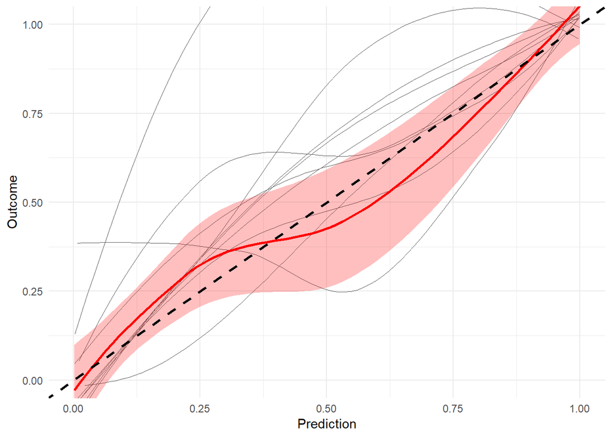

```r
enet_model$plot
```

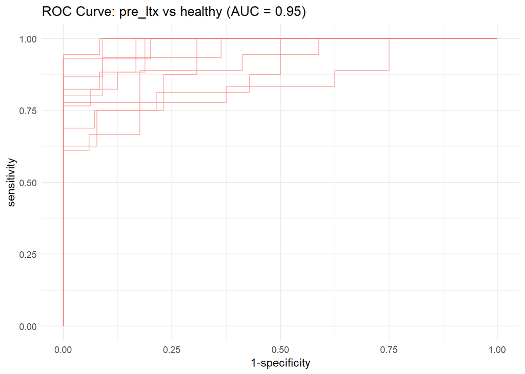

```r
roc_c
```

##### pre_ltx vs post_ltx

```r
group <- c("pre_ltx","post_ltx")
comparison_name <- paste0(group[1], " vs ",group[2])
```

```r
model_name <- paste(comparison_name,level,segment)

# prepare the data
filt_ileum_uni_data <- binomial_prep(ileum_genus_tab,
                                     ileum_genus_taxa_tab,
                                     ileum_metadata,
                                     group,
                                     usage="ml_clr")
```

```
## Removing 30 ASV(s)
```

```
## Removing 5 ASV(s)
```

```r
# fit the model
enet_model <- glmnet_binomial(filt_ileum_uni_data,
                              sample_method = "atypboot",
                              outcome="Group", N=10,
                              reuse=TRUE,
                              file=model_name,
                              Q="Q1_norway")

# ROC
roc_c <- roc_curve(enet_model, group)
# save the results
models_summ[[model_name]] <- enet_model$model_summary
models_cm[[model_name]] <- enet_model$conf_matrices$original
roc_cs[[model_name]] <- enet_model$kfold_rocobjs
betas[[model_name]] <- as.matrix(enet_model$betas)

# see the results
enet_model$model_summary %>% t()
```

```
##                                       [,1]
## alpha                           1.00000000
## lambda                          0.04853802
## auc                             0.99879227
## auc_czech                              NaN
## auc_no                          0.99879227
## auc_optimism_corrected          0.96852373
## auc_optimism_corrected_CIL      0.90471524
## auc_optimism_corrected_CIU      1.00000000
## accuracy                        0.95121951
## accuracy_czech                         NaN
## accuracy_no                     0.95121951
## accuracy_optimism_corrected     0.89068802
## accuracy_optimism_corrected_CIL 0.81005245
## accuracy_optimism_corrected_CIU 0.95270833
```

```r
enet_model$conf_matrices
```

```
## $original
##     Predicted
## True  0  1
##    0 36  0
##    1  4 42
##
## $czech
## [1] NaN
##
## $no
##     Predicted
## True  0  1
##    0 36  0
##    1  4 42
```

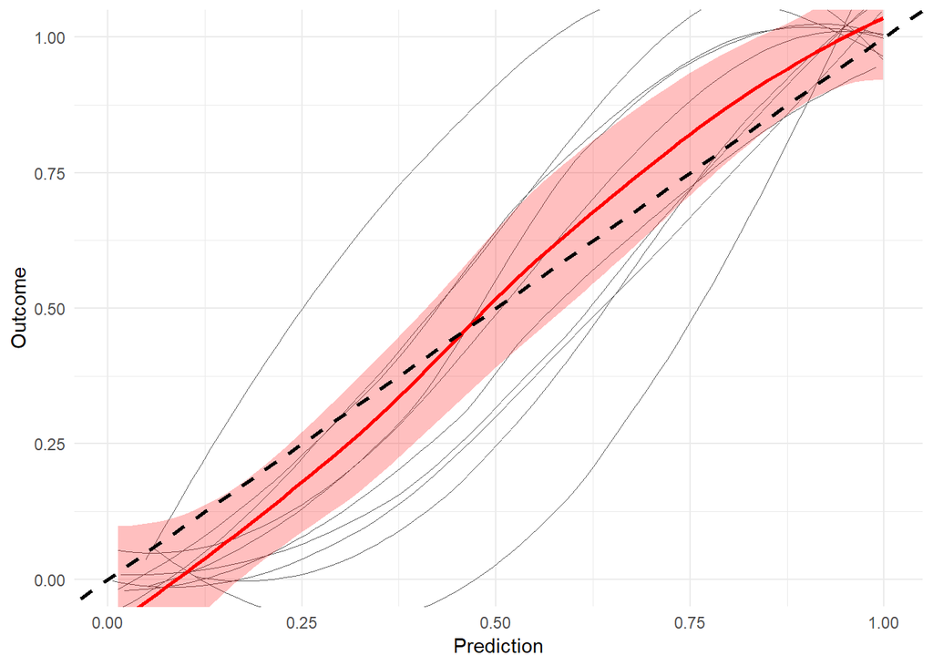

```r
enet_model$plot
```

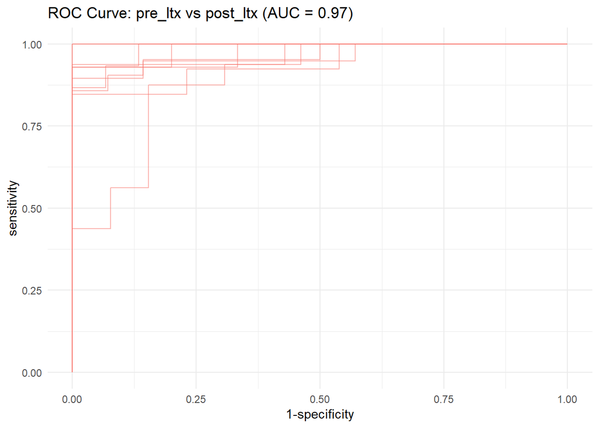

```r
roc_c
```

##### post_ltx vs healthy

```r
group <- c("post_ltx","healthy")
comparison_name <- paste0(group[1], " vs ",group[2])
```

```r
model_name <- paste(comparison_name,level,segment)

# prepare the data
filt_ileum_uni_data <- binomial_prep(ileum_genus_tab,
                                     ileum_genus_taxa_tab,
                                     ileum_metadata,group,
                                     usage="ml_clr")
```

```
## Removing 53 ASV(s)
```

```
## Removing 5 ASV(s)
```

```r
# fit the model
enet_model <- glmnet_binomial(filt_ileum_uni_data,
                              sample_method = "atypboot",
                              outcome="Group",
                              N=10,
                              reuse=TRUE,
                              file=model_name,
                              Q="Q1_norway")

# ROC
roc_c <- roc_curve(enet_model, group)
# save the results
models_summ[[model_name]] <- enet_model$model_summary
models_cm[[model_name]] <- enet_model$conf_matrices$original
roc_cs[[model_name]] <- enet_model$kfold_rocobjs
betas[[model_name]] <- as.matrix(enet_model$betas)

# see the results
enet_model$model_summary %>% t()
```

```
##                                      [,1]
## alpha                           0.2000000
## lambda                          0.1915607
## auc                             1.0000000
## auc_czech                             NaN
## auc_no                          1.0000000
## auc_optimism_corrected          0.9177772
## auc_optimism_corrected_CIL      0.7889323
## auc_optimism_corrected_CIU      0.9922890
## accuracy                        1.0000000
## accuracy_czech                        NaN
## accuracy_no                     1.0000000
## accuracy_optimism_corrected     0.8372821
## accuracy_optimism_corrected_CIL 0.6505357
## accuracy_optimism_corrected_CIU 0.9577500
```

```r
enet_model$conf_matrices
```

```
## $original
##     Predicted
## True  0  1
##    0 36  0
##    1  0 36
##
## $czech
## [1] NaN
##
## $no
##     Predicted
## True  0  1
##    0 36  0
##    1  0 36
```

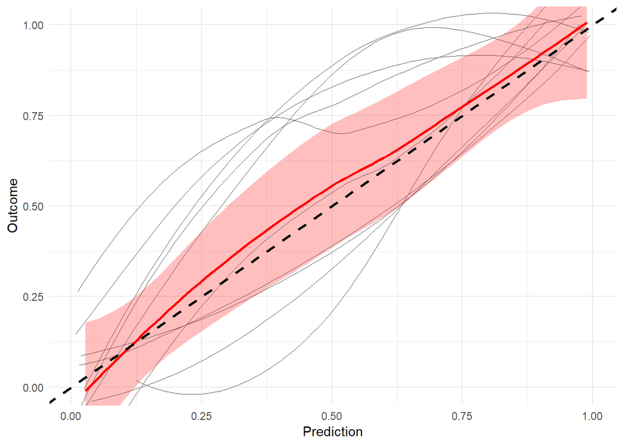

```r
enet_model$plot
```

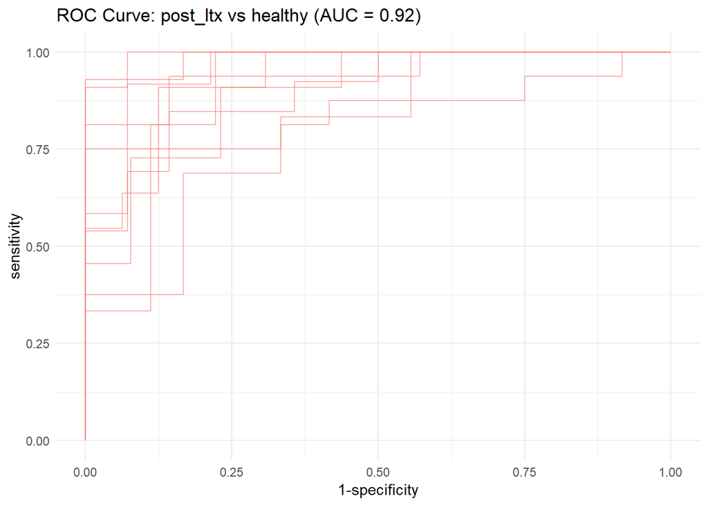

```r
roc_c
```

#### Saving results

```r
models_summ_df_ileum <- do.call(rbind,
  models_summ[grep(segment,names(models_summ),value = TRUE)])

write.csv(models_summ_df_ileum,file.path(path,paste0("elastic_net_",segment,".csv")))
```

### Supplementary models

```r
supplements_models <- list()
```

#### CLR-transformed data

##### kNN

```r
model="knn"
```

###### ASV level

```r
level="ASV"
```

*pre_ltx vs healthy*

```r
group <- c("pre_ltx","healthy")
comparison_name <- paste0(group[1], " vs ",group[2])
```

```r
model_name <- paste(comparison_name,level,segment)

# prepare the data
filt_ileum_uni_data <- binomial_prep(ileum_asv_tab,
                                     ileum_taxa_tab,
                                     ileum_metadata,
                                     group, usage="ml_clr")
```

```
## Removing 532 ASV(s)
```

```
## Removing 83 ASV(s)
```

```r
# fit the model
knn_model <- knn_binomial(filt_ileum_uni_data,
                              sample_method = "atypboot",
                              outcome="Group",
                              N=10,
                              reuse=TRUE,
                              file=model_name,
                              Q="Q1_norway")

# ROC curve
roc_c <- roc_curve(knn_model, group)
# save the results
supplements_models[["models_summ"]][["knn_model"]][[model_name]] <- knn_model$model_summary
supplements_models[["roc_cs"]][["knn_model"]][[model_name]] <- knn_model$kfold_rocobjs

# see the results
knn_model$model_summary %>% t()
```

```
##                                       [,1]
## k                               15.0000000
## auc                              0.9471618
## auc_optimism_corrected           0.8688287
## auc_optimism_corrected_CIL       0.7812429
## auc_optimism_corrected_CIU       0.9217320
## accuracy                         0.8902439
## accuracy_optimism_corrected      0.7729655
## accuracy_optimism_corrected_CIL  0.6567308
## accuracy_optimism_corrected_CIU  0.8432692
```

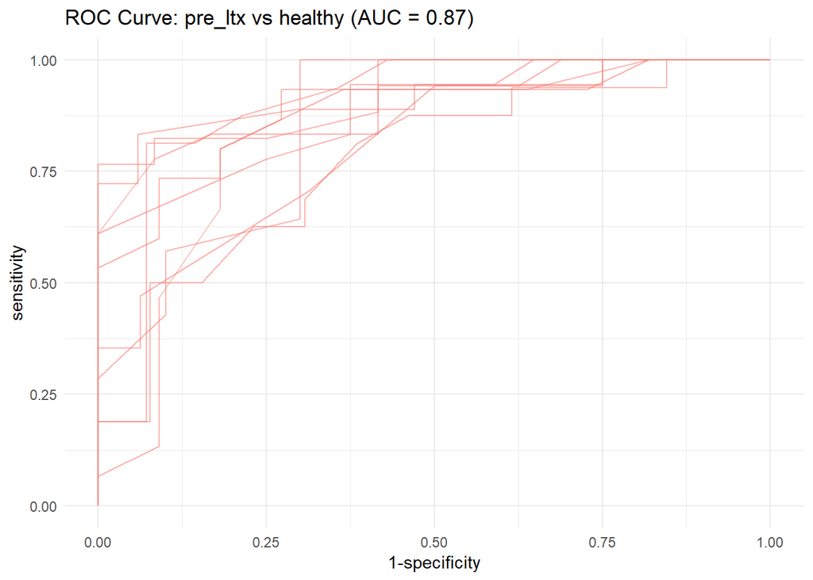

```r
roc_c
```

**pre_ltx vs post_ltx**

```r
group <- c("pre_ltx","post_ltx")
comparison_name <- paste0(group[1], " vs ",group[2])
```

```r
model_name <- paste(comparison_name,level,segment)


# prepare the data
filt_ileum_uni_data <- binomial_prep(ileum_asv_tab,
                                     ileum_taxa_tab,
                                     ileum_metadata,
                                     group, usage="ml_clr")
```

```
## Removing 798 ASV(s)
```

```
## Removing 48 ASV(s)
```

```r
# fit the model
knn_model <- knn_binomial(filt_ileum_uni_data,
                              sample_method = "atypboot",
                              outcome="Group",
                              N=10,
                              reuse=TRUE,
                              file=model_name,
                              Q="Q1_norway")

# ROC curve
roc_c <- roc_curve(knn_model, group)
# save the results
supplements_models[["models_summ"]][["knn_model"]][[model_name]] <- knn_model$model_summary
supplements_models[["roc_cs"]][["knn_model"]][[model_name]] <- knn_model$kfold_rocobjs


# see the results
knn_model$model_summary %>% t()
```

```
##                                       [,1]
## k                               29.0000000
## auc                              0.8916063
## auc_optimism_corrected           0.7733049
## auc_optimism_corrected_CIL       0.6753055
## auc_optimism_corrected_CIU       0.8794286
## accuracy                         0.8170732
## accuracy_optimism_corrected      0.6834489
## accuracy_optimism_corrected_CIL  0.5821154
## accuracy_optimism_corrected_CIU  0.7629167
```

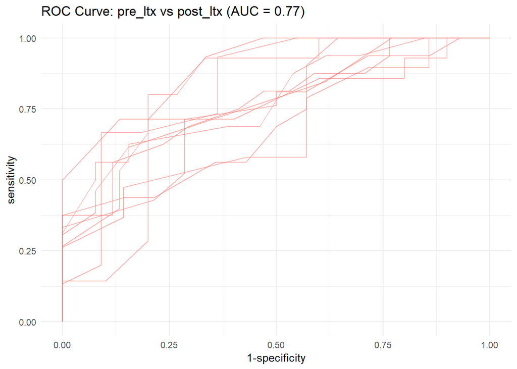

```r
roc_c
```

**post_ltx vs healthy**

```r
group <- c("post_ltx","healthy")
comparison_name <- paste0(group[1], " vs ",group[2])
```

```r
model_name <- paste(comparison_name,level,segment)

# prepare the data
filt_ileum_uni_data <- binomial_prep(ileum_asv_tab,
                                     ileum_taxa_tab,
                                     ileum_metadata,
                                     group, usage="ml_clr")
```

```
## Removing 582 ASV(s)
```

```
## Removing 94 ASV(s)
```

```r
# fit the model
knn_model <- knn_binomial(filt_ileum_uni_data,
                              sample_method = "atypboot",
                              outcome="Group",
                              N=10,
                              reuse=TRUE,
                              file=model_name,
                              Q="Q1_norway")

# ROC curve
roc_c <- roc_curve(knn_model, group)
# save the results
# save the results
supplements_models[["models_summ"]][["knn_model"]][[model_name]] <- knn_model$model_summary
supplements_models[["roc_cs"]][["knn_model"]][[model_name]] <- knn_model$kfold_rocobjs

# see the results
knn_model$model_summary %>% t()
```

```
##                                       [,1]
## k                               23.0000000
## auc                              0.9390432
## auc_optimism_corrected           0.8979242
## auc_optimism_corrected_CIL       0.7785511
## auc_optimism_corrected_CIU       0.9974888
## accuracy                         0.8750000
## accuracy_optimism_corrected      0.7897957
## accuracy_optimism_corrected_CIL  0.6150000
## accuracy_optimism_corrected_CIU  0.9387500
```

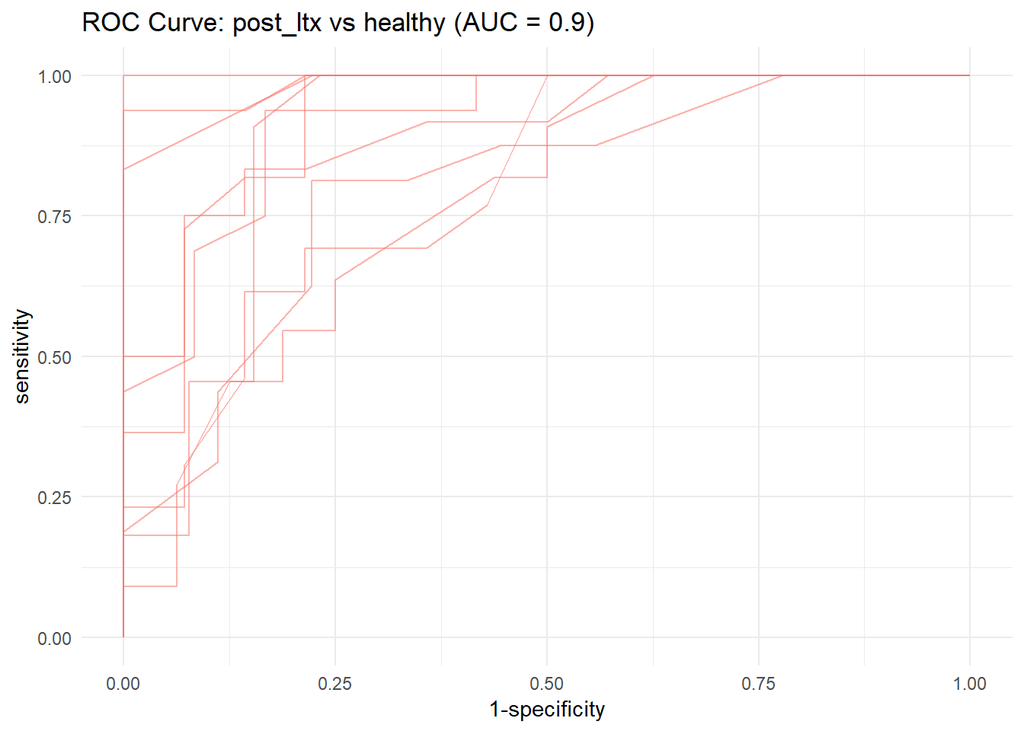

```r
roc_c
```

###### Genus level

```r
level="genus"
```

Aggregate taxa

```r
genus_data <- aggregate_taxa(ileum_asv_tab,
                             ileum_taxa_tab,
                             taxonomic_level = level)

ileum_genus_tab <- genus_data[[1]]
ileum_genus_taxa_tab <- genus_data[[2]]
```

**pre_ltx vs healthy**

```r
group <- c("pre_ltx","healthy")
comparison_name <- paste0(group[1], " vs ",group[2])
```

```r
model_name <- paste(comparison_name,level,segment)

# prepare the data
filt_ileum_uni_data <- binomial_prep(ileum_genus_tab,
                                     ileum_genus_taxa_tab,
                                     ileum_metadata,
                                     group,
                                     usage="ml_clr")
```

```
## Removing 37 ASV(s)
```

```
## Removing 6 ASV(s)
```

```r
# fit the model
knn_model <- knn_binomial(filt_ileum_uni_data,
                              sample_method = "atypboot",
                              outcome="Group",
                              N=10,
                              reuse=TRUE,
                              file=model_name,
                              Q="Q1_norway")

# ROC curve
roc_c <- roc_curve(knn_model, group)
# save the results
supplements_models[["models_summ"]][["knn_model"]][[model_name]] <- knn_model$model_summary
supplements_models[["roc_cs"]][["knn_model"]][[model_name]] <- knn_model$kfold_rocobjs


# see the results
knn_model$model_summary %>% t()
```

```
##                                       [,1]
## k                               29.0000000
## auc                              0.9465580
## auc_optimism_corrected           0.8917541
## auc_optimism_corrected_CIL       0.7452390
## auc_optimism_corrected_CIU       0.9640501
## accuracy                         0.7926829
## accuracy_optimism_corrected      0.7719603
## accuracy_optimism_corrected_CIL  0.6541446
## accuracy_optimism_corrected_CIU  0.9035714
```

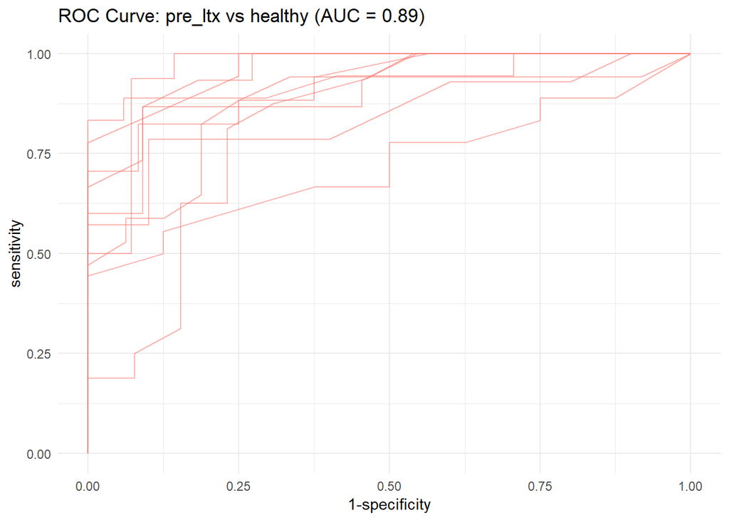

```r
roc_c
```

**pre_ltx vs post_ltx**

```r
group <- c("pre_ltx","post_ltx")
comparison_name <- paste0(group[1], " vs ",group[2])
```

```r
model_name <- paste(comparison_name,level,segment)

# prepare the data
filt_ileum_uni_data <- binomial_prep(ileum_genus_tab,
                                     ileum_genus_taxa_tab,
                                     ileum_metadata,
                                     group,
                                     usage="ml_clr")
```

```
## Removing 30 ASV(s)
```

```
## Removing 5 ASV(s)
```

```r
# fit the model
knn_model <- knn_binomial(filt_ileum_uni_data,
                              sample_method = "atypboot",
                              outcome="Group",
                              N=10,
                              reuse=TRUE,
                              file=model_name,
                              Q="Q1_norway")

# ROC curve
roc_c <- roc_curve(knn_model, group)
# save the results
supplements_models[["models_summ"]][["knn_model"]][[model_name]] <- knn_model$model_summary
supplements_models[["roc_cs"]][["knn_model"]][[model_name]] <- knn_model$kfold_rocobjs


# see the results
knn_model$model_summary %>% t()
```

```
##                                       [,1]
## k                               22.0000000
## auc                              0.8786232
## auc_optimism_corrected           0.7599639
## auc_optimism_corrected_CIL       0.6547210
## auc_optimism_corrected_CIU       0.9204762
## accuracy                         0.7804878
## accuracy_optimism_corrected      0.6637893
## accuracy_optimism_corrected_CIL  0.5812121
## accuracy_optimism_corrected_CIU  0.7903846
```

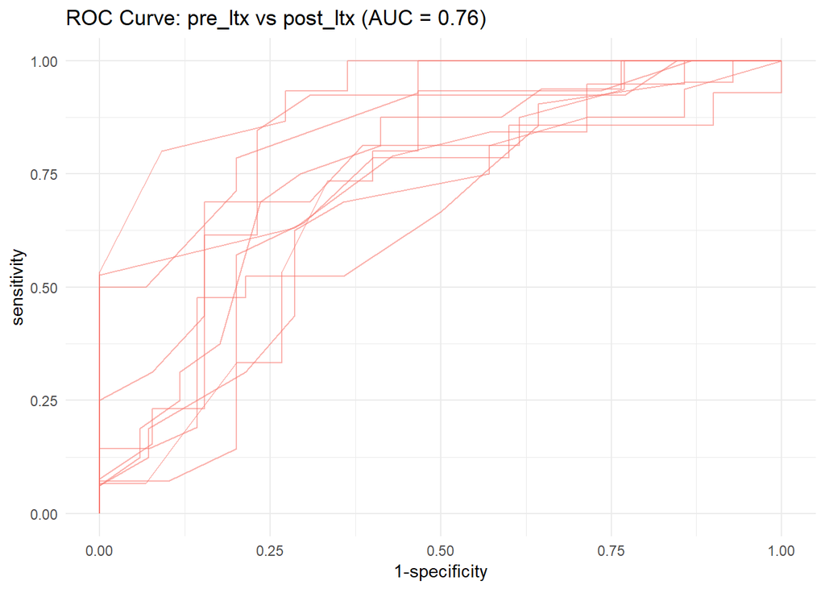

```r
roc_c
```

**post_ltx vs healthy**

```r
group <- c("post_ltx","healthy")
comparison_name <- paste0(group[1], " vs ",group[2])
```

```r
model_name <- paste(comparison_name,level,segment)

# prepare the data
filt_ileum_uni_data <- binomial_prep(ileum_genus_tab,
                                     ileum_genus_taxa_tab,
                                     ileum_metadata,
                                     group,
                                     usage="ml_clr")
```

```
## Removing 53 ASV(s)
```

```
## Removing 5 ASV(s)
```

```r
# fit the model
knn_model <- knn_binomial(filt_ileum_uni_data,
                              sample_method = "atypboot",
                              outcome="Group",
                              N=10,
                              reuse=TRUE,
                              file=model_name,
                              Q="Q1_norway")

# ROC curve
roc_c <- roc_curve(knn_model, group)
# save the results
supplements_models[["models_summ"]][["knn_model"]][[model_name]] <- knn_model$model_summary
supplements_models[["roc_cs"]][["knn_model"]][[model_name]] <- knn_model$kfold_rocobjs


# see the results
knn_model$model_summary %>% t()
```

```
##                                       [,1]
## k                               10.0000000
## auc                              0.9614198
## auc_optimism_corrected           0.9134301
## auc_optimism_corrected_CIL       0.8567854
## auc_optimism_corrected_CIU       0.9878517
## accuracy                         0.8194444
## accuracy_optimism_corrected      0.7624438
## accuracy_optimism_corrected_CIL  0.6096429
## accuracy_optimism_corrected_CIU  0.9352500
```

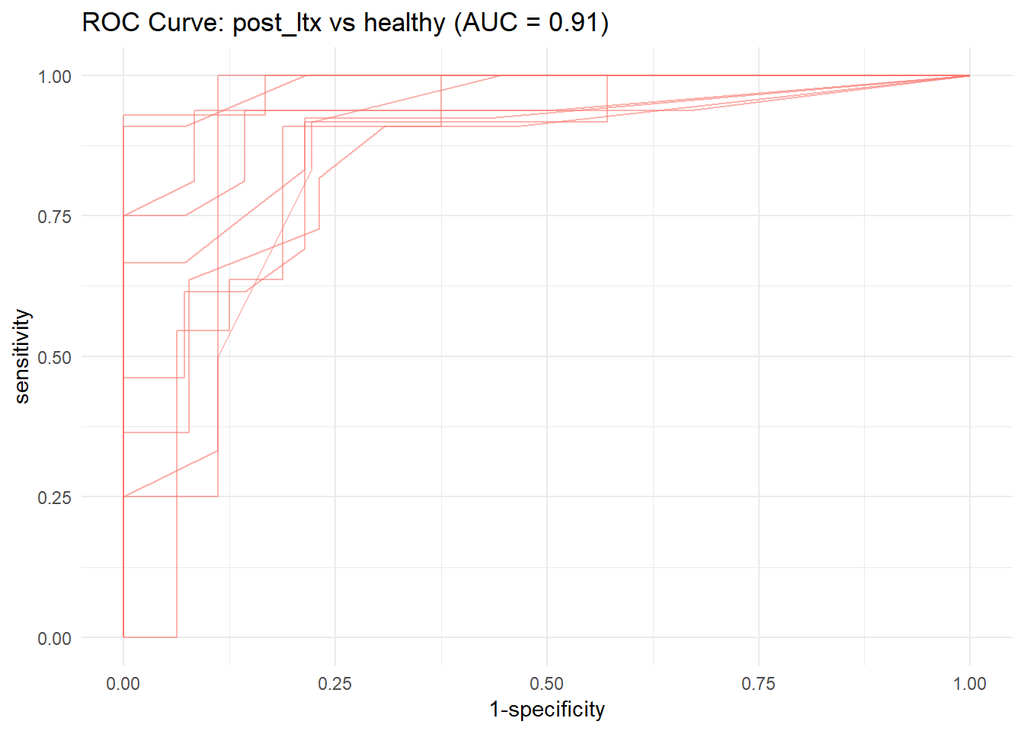

```r
roc_c
```

##### Random Forest

```r
model="rf"
```

###### ASV level

```r
level="ASV"
```

*pre_ltx vs healthy*

```r
group <- c("pre_ltx","healthy")
comparison_name <- paste0(group[1], " vs ",group[2])
```

```r
model_name <- paste(comparison_name,level,segment)

# prepare the data
filt_ileum_uni_data <- binomial_prep(ileum_asv_tab,
                                     ileum_taxa_tab,
                                     ileum_metadata,
                                     group, usage="ml_clr")
```

```
## Removing 532 ASV(s)
```

```
## Removing 83 ASV(s)
```

```r
# fit the model
rf_model <- rf_binomial(filt_ileum_uni_data,
                              sample_method = "atypboot",
                              outcome="Group",
                              N=10,
                              reuse=TRUE,
                              file=model_name,
                              Q="Q1_norway")

# ROC curve
roc_c <- roc_curve(rf_model, group)
# save the results
supplements_models[["models_summ"]][["rf_model"]][[model_name]] <- rf_model$model_summary
supplements_models[["roc_cs"]][["rf_model"]][[model_name]] <- rf_model$kfold_rocobjs

# see the results
rf_model$model_summary %>% t()
```

```
##                                 [,1]
## mtry                            "131"
## splitrule                       "gini"
## min.node.size                   "2"
## auc                             "1"
## auc_optimism_corrected          "0.9460283"
## auc_optimism_corrected_CIL      "0.8288603"
## auc_optimism_corrected_CIU      "0.9936959"
## accuracy                        "1"
## accuracy_optimism_corrected     "0.8566836"
## accuracy_optimism_corrected_CIL "0.7280594"
## accuracy_optimism_corrected_CIU "0.9608173"
```

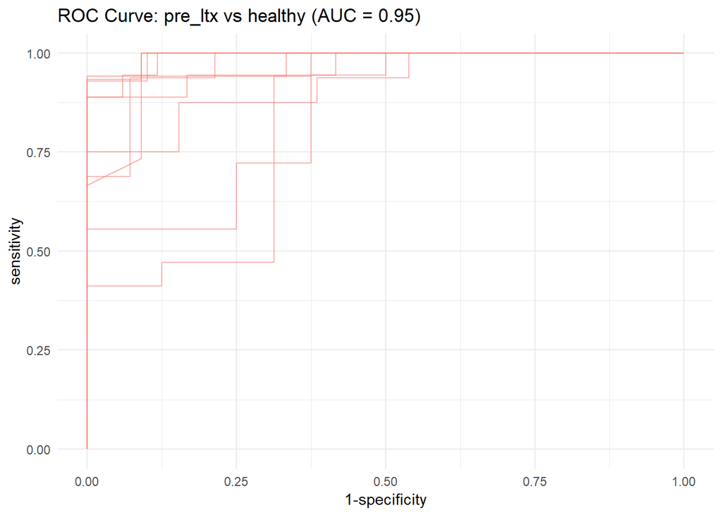

```r
roc_c
```

**pre_ltx vs post_ltx**

```r
group <- c("pre_ltx","post_ltx")
comparison_name <- paste0(group[1], " vs ",group[2])
```

```r
model_name <- paste(comparison_name,level,segment)

# prepare the data
filt_ileum_uni_data <- binomial_prep(ileum_asv_tab,
                                     ileum_taxa_tab,
                                     ileum_metadata,
                                     group, usage="ml_clr")
```

```
## Removing 798 ASV(s)
```

```
## Removing 48 ASV(s)
```

```r
# fit the model
rf_model <- rf_binomial(filt_ileum_uni_data,
                              sample_method = "atypboot",
                              outcome="Group",
                              N=10,
                              reuse=TRUE,
                              file=model_name,
                              Q="Q1_norway")

# ROC curve
roc_c <- roc_curve(rf_model, group)
# save the results
supplements_models[["models_summ"]][["rf_model"]][[model_name]] <- rf_model$model_summary
supplements_models[["roc_cs"]][["rf_model"]][[model_name]] <- rf_model$kfold_rocobjs

# see the results
rf_model$model_summary %>% t()
```

```
##                                 [,1]
## mtry                            "145"
## splitrule                       "gini"
## min.node.size                   "5"
## auc                             "1"
## auc_optimism_corrected          "0.9413764"
## auc_optimism_corrected_CIL      "0.8901268"
## auc_optimism_corrected_CIU      "0.990127"
## accuracy                        "1"
## accuracy_optimism_corrected     "0.9077304"
## accuracy_optimism_corrected_CIL "0.8076923"
## accuracy_optimism_corrected_CIU "0.9655128"
```

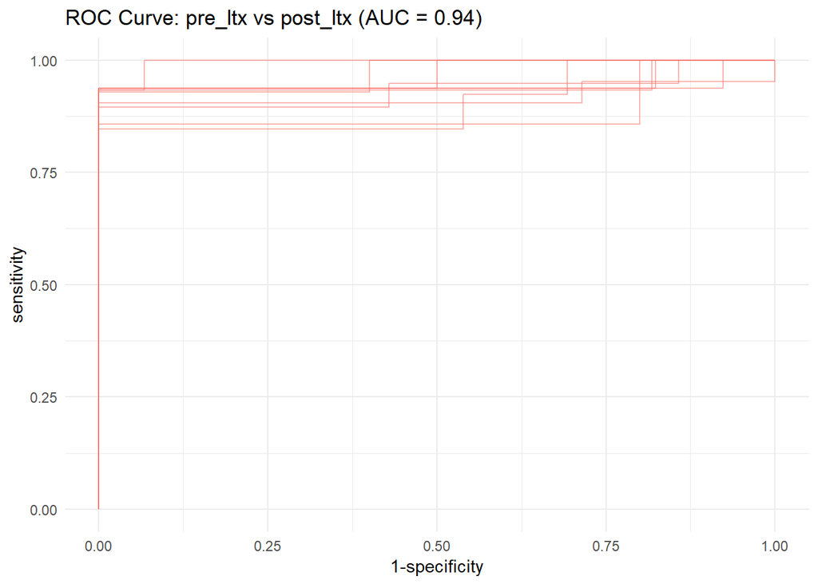

```r
roc_c
```

**post_ltx vs healthy**

```r
group <- c("post_ltx","healthy")
comparison_name <- paste0(group[1], " vs ",group[2])
```

```r
model_name <- paste(comparison_name,level,segment)

# prepare the data
filt_ileum_uni_data <- binomial_prep(ileum_asv_tab,
                                     ileum_taxa_tab,
                                     ileum_metadata,
                                     group, usage="ml_clr")
```

```
## Removing 582 ASV(s)
```

```
## Removing 94 ASV(s)
```

```r
# fit the model
rf_model <- rf_binomial(filt_ileum_uni_data,
                              sample_method = "atypboot",
                              outcome="Group",
                              N=10,
                              reuse=TRUE,
                              file=model_name,
                              Q="Q1_norway")

# ROC curve
roc_c <- roc_curve(rf_model, group)
# save the results
supplements_models[["models_summ"]][["rf_model"]][[model_name]] <- rf_model$model_summary
supplements_models[["roc_cs"]][["rf_model"]][[model_name]] <- rf_model$kfold_rocobjs

# see the results
rf_model$model_summary %>% t()
```

```
##                                 [,1]
## mtry                            "483"
## splitrule                       "gini"
## min.node.size                   "2"
## auc                             "1"
## auc_optimism_corrected          "0.9255632"
## auc_optimism_corrected_CIL      "0.8548363"
## auc_optimism_corrected_CIU      "1"
## accuracy                        "1"
## accuracy_optimism_corrected     "0.7760814"
## accuracy_optimism_corrected_CIL "0.5868571"
## accuracy_optimism_corrected_CIU "0.913"
```

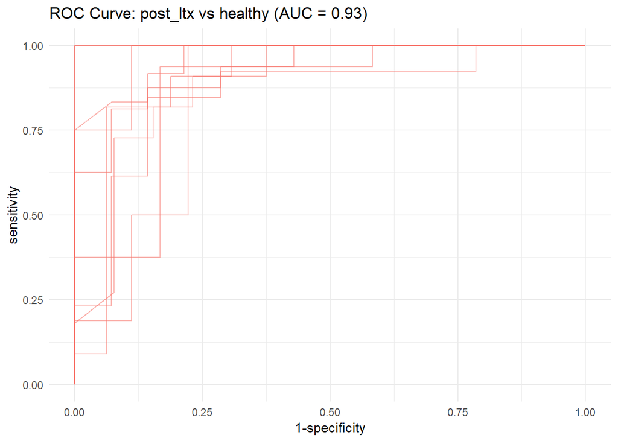

```r
roc_c
```

###### Genus level

```r
level="genus"
```

Aggregate taxa

```r
genus_data <- aggregate_taxa(ileum_asv_tab,
                             ileum_taxa_tab,
                             taxonomic_level = level)

ileum_genus_tab <- genus_data[[1]]
ileum_genus_taxa_tab <- genus_data[[2]]
```

**pre_ltx vs healthy**

```r
group <- c("pre_ltx","healthy")
comparison_name <- paste0(group[1], " vs ",group[2])
```

```r
model_name <- paste(comparison_name,level,segment)

# prepare the data
filt_ileum_uni_data <- binomial_prep(ileum_genus_tab,
                                     ileum_genus_taxa_tab,
                                     ileum_metadata,
                                     group,
                                     usage="ml_clr")
```

```
## Removing 37 ASV(s)
```

```
## Removing 6 ASV(s)
```

```r
# fit the model
rf_model <- rf_binomial(filt_ileum_uni_data,
                              sample_method = "atypboot",
                              outcome="Group",
                              N=10,
                              reuse=TRUE,
                              file=model_name,
                              Q="Q1_norway")

# ROC curve
roc_c <- roc_curve(rf_model, group)
# save the results
supplements_models[["models_summ"]][["rf_model"]][[model_name]] <- rf_model$model_summary
supplements_models[["roc_cs"]][["rf_model"]][[model_name]] <- rf_model$kfold_rocobjs

# see the results
rf_model$model_summary %>% t()
```

```
##                                 [,1]
## mtry                            "53"
## splitrule                       "gini"
## min.node.size                   "5"
## auc                             "1"
## auc_optimism_corrected          "0.957942"
## auc_optimism_corrected_CIL      "0.8537879"
## auc_optimism_corrected_CIU      "0.9953091"
## accuracy                        "1"
## accuracy_optimism_corrected     "0.8762018"
## accuracy_optimism_corrected_CIL "0.7802448"
## accuracy_optimism_corrected_CIU "0.9582759"
```

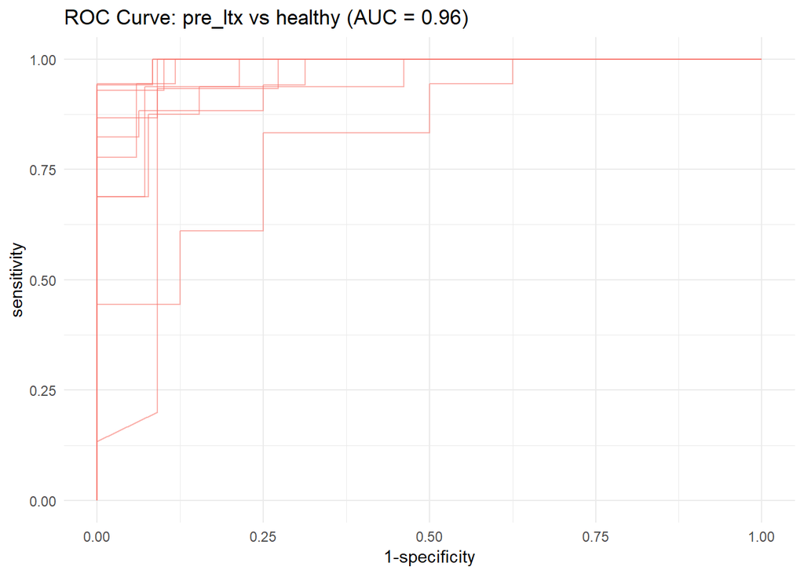

```r
roc_c
```

**pre_ltx vs post_ltx**

```r
group <- c("pre_ltx","post_ltx")
comparison_name <- paste0(group[1], " vs ",group[2])
```

```r
model_name <- paste(comparison_name,level,segment)

# prepare the data
filt_ileum_uni_data <- binomial_prep(ileum_genus_tab,
                                     ileum_genus_taxa_tab,
                                     ileum_metadata,
                                     group,
                                     usage="ml_clr")
```

```
## Removing 30 ASV(s)
```

```
## Removing 5 ASV(s)
```

```r
# fit the model
rf_model <- rf_binomial(filt_ileum_uni_data,
                              sample_method = "atypboot",
                              outcome="Group",
                              N=10,
                              reuse=TRUE,
                              file=model_name,
                              Q="Q1_norway")

# ROC curve
roc_c <- roc_curve(rf_model, group)
# save the results
supplements_models[["models_summ"]][["rf_model"]][[model_name]] <- rf_model$model_summary
supplements_models[["roc_cs"]][["rf_model"]][[model_name]] <- rf_model$kfold_rocobjs

# see the results
rf_model$model_summary %>% t()
```

```
##                                 [,1]
## mtry                            "49"
## splitrule                       "gini"
## min.node.size                   "2"
## auc                             "1"
## auc_optimism_corrected          "0.9296244"
## auc_optimism_corrected_CIL      "0.9000255"
## auc_optimism_corrected_CIU      "0.956032"
## accuracy                        "1"
## accuracy_optimism_corrected     "0.8686224"
## accuracy_optimism_corrected_CIL "0.7741379"
## accuracy_optimism_corrected_CIU "0.9380303"
```

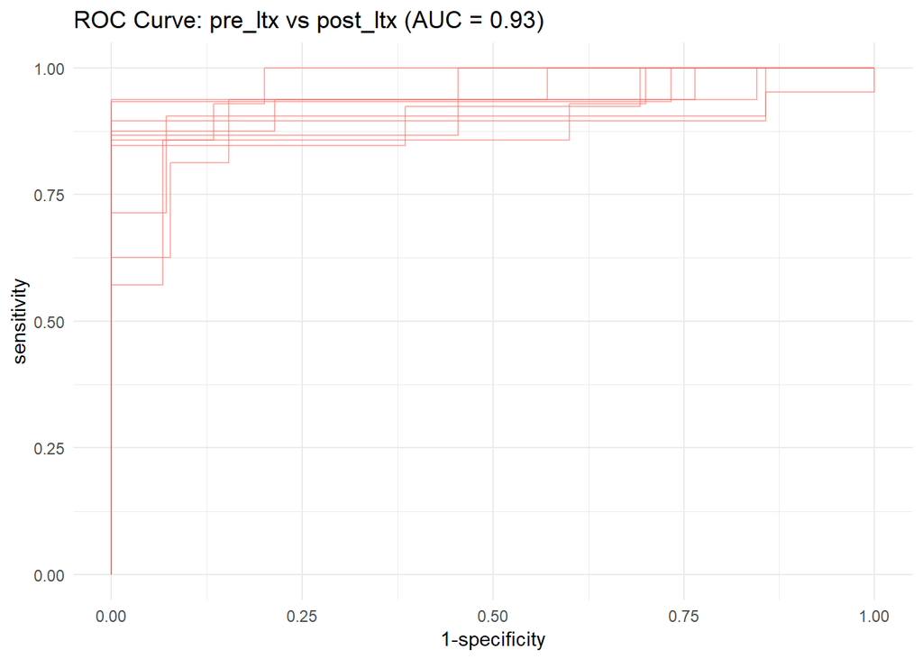

```r
roc_c
```

**post_ltx vs healthy**

```r
group <- c("post_ltx","healthy")
comparison_name <- paste0(group[1], " vs ",group[2])
```

```r
model_name <- paste(comparison_name,level,segment)

# prepare the data
filt_ileum_uni_data <- binomial_prep(ileum_genus_tab,
                                     ileum_genus_taxa_tab,
                                     ileum_metadata,
                                     group,
                                     usage="ml_clr")
```

```
## Removing 53 ASV(s)
```

```
## Removing 5 ASV(s)
```

```r
# fit the model
rf_model <- rf_binomial(filt_ileum_uni_data,
                              sample_method = "atypboot",
                              outcome="Group",
                              N=10,
                              reuse=TRUE,
                              file=model_name,
                              Q="Q1_norway")

# ROC curve
roc_c <- roc_curve(rf_model, group)
# save the results
supplements_models[["models_summ"]][["rf_model"]][[model_name]] <- rf_model$model_summary
supplements_models[["roc_cs"]][["rf_model"]][[model_name]] <- rf_model$kfold_rocobjs

# see the results
rf_model$model_summary %>% t()
```

```
##                                 [,1]
## mtry                            "191"
## splitrule                       "gini"
## min.node.size                   "2"
## auc                             "1"
## auc_optimism_corrected          "0.9271352"
## auc_optimism_corrected_CIL      "0.8579427"
## auc_optimism_corrected_CIU      "0.9946429"
## accuracy                        "1"
## accuracy_optimism_corrected     "0.8212688"
## accuracy_optimism_corrected_CIL "0.7142857"
## accuracy_optimism_corrected_CIU "0.939"
```

```r
roc_c
```

[output not shown]

##### Gradient boosting

```r
model="gb"
```

###### ASV level

```r
level="ASV"
```

*pre_ltx vs healthy*

```r
group <- c("pre_ltx","healthy")
comparison_name <- paste0(group[1], " vs ",group[2])
```

```r
model_name <- paste(comparison_name,level,segment)

# prepare the data
filt_ileum_uni_data <- binomial_prep(ileum_asv_tab,
                                     ileum_taxa_tab,
                                     ileum_metadata,
                                     group, usage="ml_clr")
```

```
## Removing 532 ASV(s)
```

```
## Removing 83 ASV(s)
```

```r
# fit the model
gbm_model <- gbm_binomial(filt_ileum_uni_data,
                              sample_method = "atypboot",
                              outcome="Group",
                              N=10,
                              reuse=TRUE,
                              file=model_name,
                              Q="Q1_norway")

# ROC curve
roc_c <- roc_curve(gbm_model, group)
# save the results
supplements_models[["models_summ"]][["gbm_model"]][[model_name]] <- gbm_model$model_summary
supplements_models[["roc_cs"]][["gbm_model"]][[model_name]] <- gbm_model$kfold_rocobjs

# see the results
gbm_model$model_summary %>% t()
```

[output not shown]

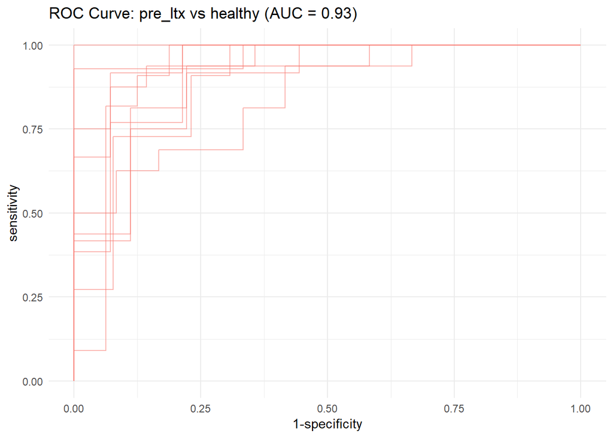

```r
roc_c
```

**pre_ltx vs post_ltx**

```r
group <- c("pre_ltx","post_ltx")
comparison_name <- paste0(group[1], " vs ",group[2])
```

```r
model_name <- paste(comparison_name,level,segment)

# prepare the data
filt_ileum_uni_data <- binomial_prep(ileum_asv_tab,
                                     ileum_taxa_tab,
                                     ileum_metadata,
                                     group, usage="ml_clr")
```

```
## Removing 798 ASV(s)
```

```
## Removing 48 ASV(s)
```

```r
# fit the model
gbm_model <- gbm_binomial(filt_ileum_uni_data,
                              sample_method = "atypboot",
                              outcome="Group",
                              N=10,
                              reuse=TRUE,
                              file=model_name,
                              Q="Q1_norway")

# ROC curve
roc_c <- roc_curve(gbm_model, group)
# save the results
supplements_models[["models_summ"]][["gbm_model"]][[model_name]] <- gbm_model$model_summary
supplements_models[["roc_cs"]][["gbm_model"]][[model_name]] <- gbm_model$kfold_rocobjs


# see the results
gbm_model$model_summary %>% t()
```

[output not shown]

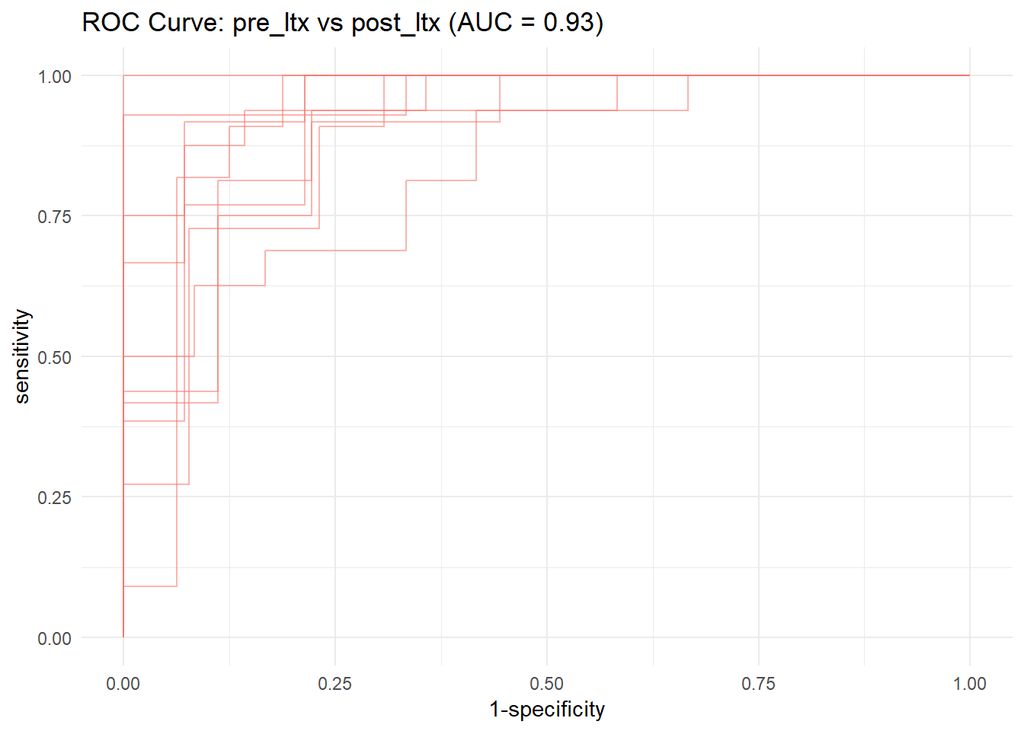

```r
roc_c
```

**post_ltx vs healthy**

```r
group <- c("post_ltx","healthy")
comparison_name <- paste0(group[1], " vs ",group[2])
```

```r
model_name <- paste(comparison_name,level,segment)

# prepare the data
filt_ileum_uni_data <- binomial_prep(ileum_asv_tab,
                                     ileum_taxa_tab,
                                     ileum_metadata,
                                     group, usage="ml_clr")
```

```
## Removing 582 ASV(s)
```

```
## Removing 94 ASV(s)
```

```r
# fit the model
gbm_model <- gbm_binomial(filt_ileum_uni_data,
                              sample_method = "atypboot",
                              outcome="Group",
                              N=10,
                              reuse=TRUE,
                              file=model_name,
                              Q="Q1_norway")

# ROC curve
roc_c <- roc_curve(gbm_model, group)
# save the results
supplements_models[["models_summ"]][["gbm_model"]][[model_name]] <- gbm_model$model_summary
supplements_models[["roc_cs"]][["gbm_model"]][[model_name]] <- gbm_model$kfold_rocobjs


# see the results
gbm_model$model_summary %>% t()
```

[output not shown]

```r
roc_c
```

[output not shown]

###### Genus level

```r
level="genus"
```

Aggregate taxa

```r
genus_data <- aggregate_taxa(ileum_asv_tab,
                             ileum_taxa_tab,
                             taxonomic_level = level)

ileum_genus_tab <- genus_data[[1]]
ileum_genus_taxa_tab <- genus_data[[2]]
```

**pre_ltx vs healthy**

```r
group <- c("pre_ltx","healthy")
comparison_name <- paste0(group[1], " vs ",group[2])
```

```r
model_name <- paste(comparison_name,level,segment)

# prepare the data
filt_ileum_uni_data <- binomial_prep(ileum_genus_tab,
                                     ileum_genus_taxa_tab,
                                     ileum_metadata,
                                     group,
                                     usage="ml_clr")
```

```
## Removing 37 ASV(s)
```

```
## Removing 6 ASV(s)
```

```r
# fit the model
gbm_model <- gbm_binomial(filt_ileum_uni_data,
                              sample_method = "atypboot",
                              outcome="Group",
                              N=10,
                              reuse=TRUE,
                              file=model_name,
                              Q="Q1_norway")

# ROC curve
roc_c <- roc_curve(gbm_model, group)
# save the results
supplements_models[["models_summ"]][["gbm_model"]][[model_name]] <- gbm_model$model_summary
supplements_models[["roc_cs"]][["gbm_model"]][[model_name]] <- gbm_model$kfold_rocobjs

# see the results
gbm_model$model_summary %>% t()
```

[output not shown]

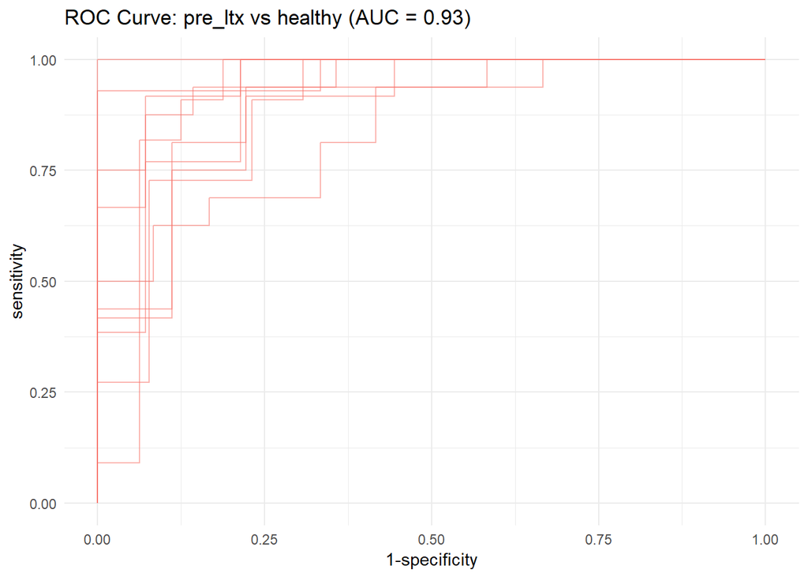

```r
roc_c
```

**pre_ltx vs post_ltx**

```r
group <- c("pre_ltx","post_ltx")
comparison_name <- paste0(group[1], " vs ",group[2])
```

```r
model_name <- paste(comparison_name,level,segment)

# prepare the data
filt_ileum_uni_data <- binomial_prep(ileum_genus_tab,
                                     ileum_genus_taxa_tab,
                                     ileum_metadata,
                                     group,
                                     usage="ml_clr")
```

```
## Removing 30 ASV(s)
```

```
## Removing 5 ASV(s)
```

```r
# fit the model
gbm_model <- gbm_binomial(filt_ileum_uni_data,
                              sample_method = "atypboot",
                              outcome="Group",
                              N=10,
                              reuse=TRUE,
                              file=model_name,
                              Q="Q1_norway")

# ROC curve
roc_c <- roc_curve(gbm_model, group)
# save the results
supplements_models[["models_summ"]][["gbm_model"]][[model_name]] <- gbm_model$model_summary
supplements_models[["roc_cs"]][["gbm_model"]][[model_name]] <- gbm_model$kfold_rocobjs

# see the results
gbm_model$model_summary %>% t()
```

[output not shown]

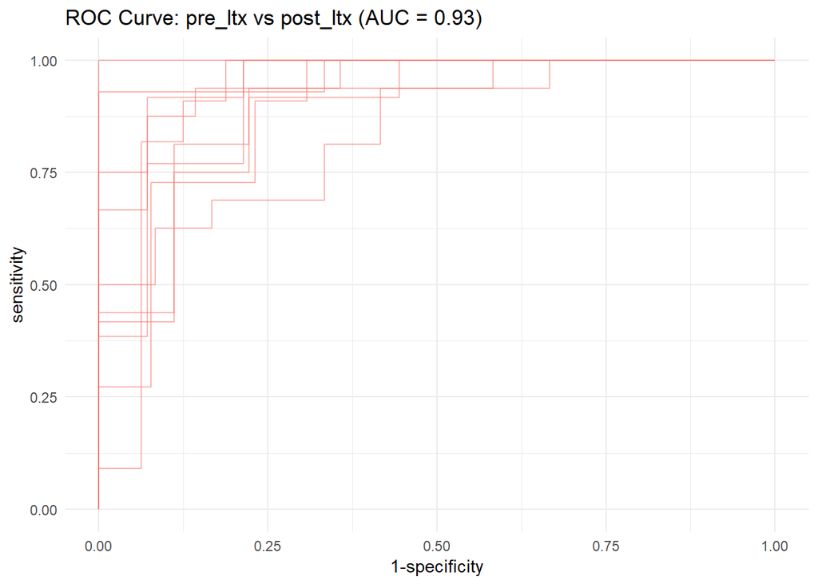

```r
roc_c
```

**post_ltx vs healthy**

```r
group <- c("post_ltx","healthy")
comparison_name <- paste0(group[1], " vs ",group[2])
```

```r
model_name <- paste(comparison_name,level,segment)

# prepare the data
filt_ileum_uni_data <- binomial_prep(ileum_genus_tab,
                                     ileum_genus_taxa_tab,
                                     ileum_metadata,
                                     group,
                                     usage="ml_clr")
```

```
## Removing 53 ASV(s)
```

```
## Removing 5 ASV(s)
```

```r
# fit the model
gbm_model <- gbm_binomial(filt_ileum_uni_data,
                              sample_method = "atypboot",
                              outcome="Group",
                              N=10,
                              reuse=TRUE,
                              file=model_name,
                              Q="Q1_norway")

# ROC curve
roc_c <- roc_curve(gbm_model, group)
# save the results
supplements_models[["models_summ"]][["gbm_model"]][[model_name]] <- gbm_model$model_summary
supplements_models[["roc_cs"]][["gbm_model"]][[model_name]] <- gbm_model$kfold_rocobjs

# see the results
gbm_model$model_summary %>% t()
```

[output not shown]

```r
roc_c
```

[output not shown]

#### Relative abundances

##### Elastic net

###### ASV level

```r
level="ASV"
```

*pre_ltx vs healthy*

```r
group <- c("pre_ltx","healthy")
comparison_name <- paste0(group[1], " vs ",group[2])
```

```r
model_name <- paste(comparison_name,level,segment)

# prepare the data
filt_ileum_uni_data <- binomial_prep(ileum_asv_tab,
                                     ileum_taxa_tab,
                                     ileum_metadata,
                                     group, usage="ml_ra")
```

```
## Removing 532 ASV(s)
```

```
## Removing 83 ASV(s)
```

```r
# fit the model
enet_model <- glmnet_binomial(filt_ileum_uni_data,
                              sample_method = "atypboot",
                              outcome="Group",
                              N=10,
                              reuse=TRUE,
                              file=model_name,
                              Q="Q1_norway")

# ROC curve
roc_c <- roc_curve(enet_model, group)
# save the results
supplements_models[["models_summ"]][["enet_model_ra"]][[model_name]] <- enet_model$model_summary

supplements_models[["roc_cs"]][["enet_model_ra"]][[model_name]] <- enet_model$kfold_rocobjs

# see the results
enet_model$model_summary %>% t()
```

```
##                                      [,1]
## alpha                           1.0000000
## lambda                          0.0754005
## auc                             1.0000000
## auc_czech                             NaN
## auc_no                          1.0000000
## auc_optimism_corrected          0.8844558
## auc_optimism_corrected_CIL      0.7700893
## auc_optimism_corrected_CIU      0.9701827
## accuracy                        0.9512195
## accuracy_czech                        NaN
## accuracy_no                     0.9512195
## accuracy_optimism_corrected     0.8028923
## accuracy_optimism_corrected_CIL 0.6619032
## accuracy_optimism_corrected_CIU 0.9250575
```

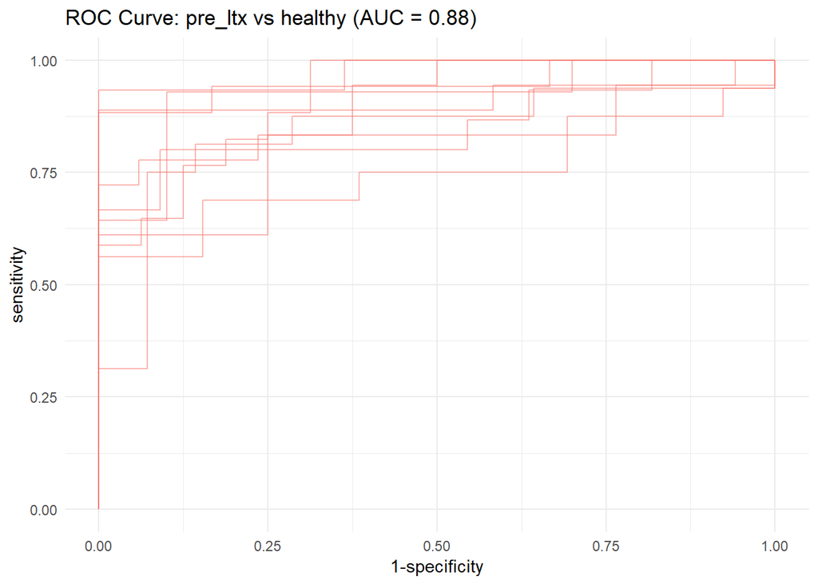

```r
roc_c
```

**pre_ltx vs post_ltx**

```r
group <- c("pre_ltx","post_ltx")
comparison_name <- paste0(group[1], " vs ",group[2])
```

```r
model_name <- paste(comparison_name,level,segment)

# prepare the data
filt_ileum_uni_data <- binomial_prep(ileum_asv_tab,
                                     ileum_taxa_tab,
                                     ileum_metadata,
                                     group, usage="ml_ra")
```

```
## Removing 798 ASV(s)
```

```
## Removing 48 ASV(s)
```

```r
# fit the model
enet_model <- glmnet_binomial(filt_ileum_uni_data,
                              sample_method = "atypboot",
                              outcome="Group",
                              N=10,
                              reuse=TRUE,
                              file=model_name,
                              Q="Q1_norway")

# ROC curve
roc_c <- roc_curve(enet_model, group)
# save the results
supplements_models[["models_summ"]][["enet_model_ra"]][[model_name]] <- enet_model$model_summary

supplements_models[["roc_cs"]][["enet_model_ra"]][[model_name]] <- enet_model$kfold_rocobjs

# see the results
enet_model$model_summary %>% t()
```

```
##                                       [,1]
## alpha                           1.00000000
## lambda                          0.09697496
## auc                             0.93417874
## auc_czech                              NaN
## auc_no                          0.93417874
## auc_optimism_corrected          0.77458515
## auc_optimism_corrected_CIL      0.56854887
## auc_optimism_corrected_CIU      0.89133955
## accuracy                        0.85365854
## accuracy_czech                         NaN
## accuracy_no                     0.85365854
## accuracy_optimism_corrected     0.70244307
## accuracy_optimism_corrected_CIL 0.65414456
## accuracy_optimism_corrected_CIU 0.77035714
```

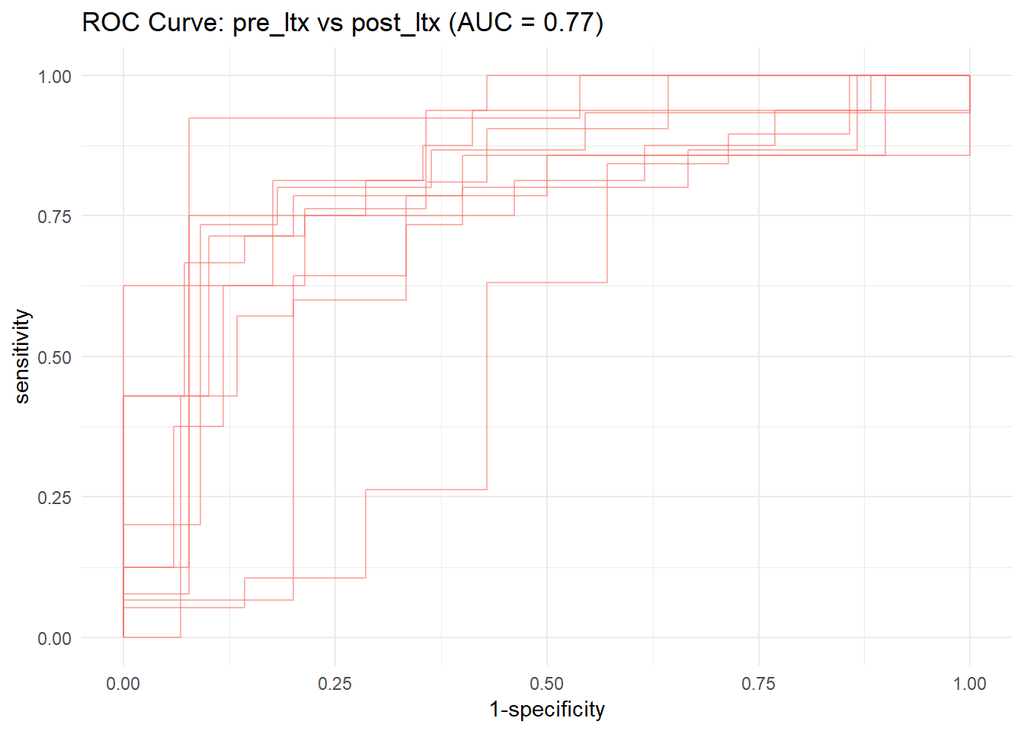

```r
roc_c
```

**post_ltx vs healthy**

```r
group <- c("post_ltx","healthy")
comparison_name <- paste0(group[1], " vs ",group[2])
```

```r
model_name <- paste(comparison_name,level,segment)


# prepare the data
filt_ileum_uni_data <- binomial_prep(ileum_asv_tab,
                                     ileum_taxa_tab,
                                     ileum_metadata,
                                     group, usage="ml_ra")
```

```
## Removing 582 ASV(s)
```

```
## Removing 94 ASV(s)
```

```r
# fit the model
enet_model <- glmnet_binomial(filt_ileum_uni_data,
                              sample_method = "atypboot",
                              outcome="Group",
                              N=10,
                              reuse=TRUE,
                              file=model_name,
                              Q="Q1_norway")

# ROC curve
roc_c <- roc_curve(enet_model, group)
# save the results
supplements_models[["models_summ"]][["enet_model_ra"]][[model_name]] <- enet_model$model_summary

supplements_models[["roc_cs"]][["enet_model_ra"]][[model_name]] <- enet_model$kfold_rocobjs

# see the results
enet_model$model_summary %>% t()
```

```
##                                      [,1]
## alpha                           0.2000000
## lambda                          0.2020060
## auc                             1.0000000
## auc_czech                             NaN
## auc_no                          1.0000000
## auc_optimism_corrected          0.8785422
## auc_optimism_corrected_CIL      0.7718256
## auc_optimism_corrected_CIU      0.9946429
## accuracy                        1.0000000
## accuracy_czech                        NaN
## accuracy_no                     1.0000000
## accuracy_optimism_corrected     0.8029910
## accuracy_optimism_corrected_CIL 0.6379630
## accuracy_optimism_corrected_CIU 0.9155000
```

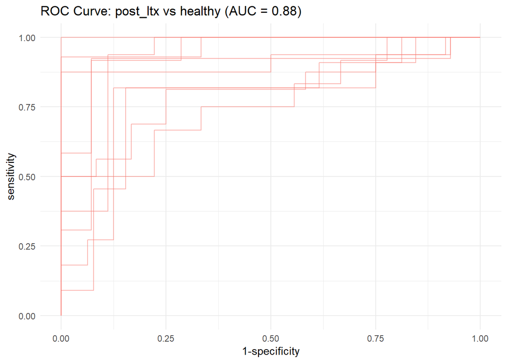

```r
roc_c
```

###### Genus level

```r
level="genus"
```

Aggregate taxa

```r
genus_data <- aggregate_taxa(ileum_asv_tab,
                             ileum_taxa_tab,
                             taxonomic_level = level)

ileum_genus_tab <- genus_data[[1]]
ileum_genus_taxa_tab <- genus_data[[2]]
```

**pre_ltx vs healthy**

```r
group <- c("pre_ltx","healthy")
comparison_name <- paste0(group[1], " vs ",group[2])
```

```r
model_name <- paste(comparison_name,level,segment)

# prepare the data
filt_ileum_uni_data <- binomial_prep(ileum_genus_tab,
                                     ileum_genus_taxa_tab,
                                     ileum_metadata,
                                     group,
                                     usage="ml_ra")
```

```
## Removing 37 ASV(s)
```

```
## Removing 6 ASV(s)
```

```r
# fit the model
enet_model <- glmnet_binomial(filt_ileum_uni_data,
                              sample_method = "atypboot",
                              outcome="Group",
                              N=10,
                              reuse=TRUE,
                              file=model_name,
                              Q="Q1_norway")

# ROC curve
roc_c <- roc_curve(enet_model, group)
# save the results
supplements_models[["models_summ"]][["enet_model_ra"]][[model_name]] <- enet_model$model_summary

supplements_models[["roc_cs"]][["enet_model_ra"]][[model_name]] <- enet_model$kfold_rocobjs

# see the results
enet_model$model_summary %>% t()
```

```
##                                       [,1]
## alpha                           0.40000000
## lambda                          0.06226444
## auc                             1.00000000
## auc_czech                              NaN
## auc_no                          1.00000000
## auc_optimism_corrected          0.90118822
## auc_optimism_corrected_CIL      0.81208129
## auc_optimism_corrected_CIU      0.99035714
## accuracy                        1.00000000
## accuracy_czech                         NaN
## accuracy_no                     1.00000000
## accuracy_optimism_corrected     0.83700920
## accuracy_optimism_corrected_CIL 0.73613636
## accuracy_optimism_corrected_CIU 0.97672414
```

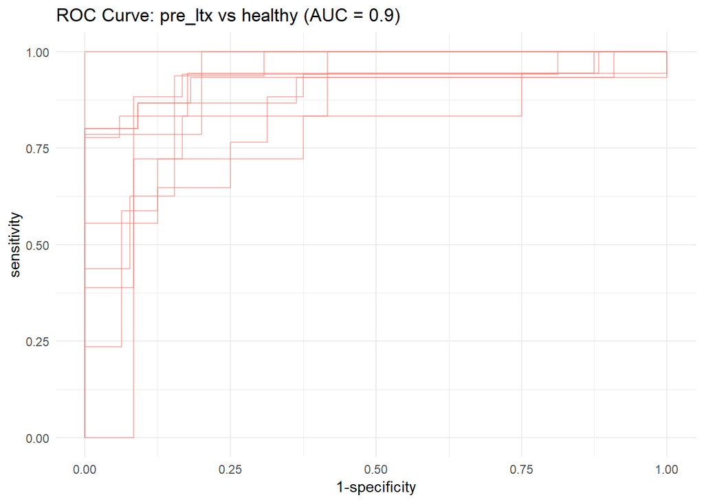

```r
roc_c
```

**pre_ltx vs post_ltx**

```r
group <- c("pre_ltx","post_ltx")
comparison_name <- paste0(group[1], " vs ",group[2])
```

```r
model_name <- paste(comparison_name,level,segment)


# prepare the data
filt_ileum_uni_data <- binomial_prep(ileum_genus_tab,
                                     ileum_genus_taxa_tab,
                                     ileum_metadata,
                                     group,
                                     usage="ml_ra")
```

```
## Removing 30 ASV(s)
```

```
## Removing 5 ASV(s)
```

```r
# fit the model
enet_model <- glmnet_binomial(filt_ileum_uni_data,
                              sample_method = "atypboot",
                              outcome="Group",
                              N=10,
                              reuse=TRUE,
                              file=model_name,
                              Q="Q1_norway")

# ROC curve
roc_c <- roc_curve(enet_model, group)
# save the results
supplements_models[["models_summ"]][["enet_model_ra"]][[model_name]] <- enet_model$model_summary

supplements_models[["roc_cs"]][["enet_model_ra"]][[model_name]] <- enet_model$kfold_rocobjs

# see the results
enet_model$model_summary %>% t()
```

```
##                                      [,1]
## alpha                           0.8000000
## lambda                          0.1018225
## auc                             0.9516908
## auc_czech                             NaN
## auc_no                          0.9516908
## auc_optimism_corrected          0.6471438
## auc_optimism_corrected_CIL      0.4931213
## auc_optimism_corrected_CIU      0.8361818
## accuracy                        0.8414634
## accuracy_czech                        NaN
## accuracy_no                     0.8414634
## accuracy_optimism_corrected     0.6077638
## accuracy_optimism_corrected_CIL 0.4663130
## accuracy_optimism_corrected_CIU 0.7984615
```

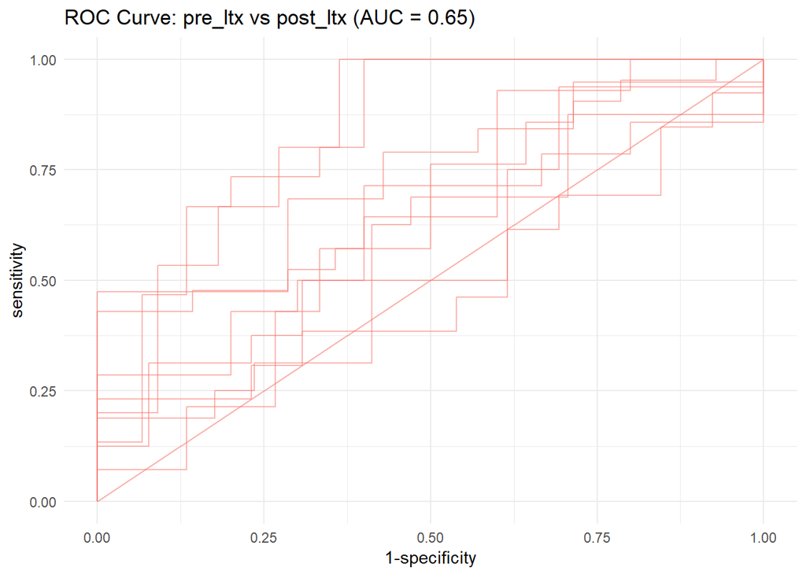

```r
roc_c
```

**post_ltx vs healthy**

```r
group <- c("post_ltx","healthy")
comparison_name <- paste0(group[1], " vs ",group[2])
```

```r
model_name <- paste(comparison_name,level,segment)

# prepare the data
filt_ileum_uni_data <- binomial_prep(ileum_genus_tab,
                                     ileum_genus_taxa_tab,
                                     ileum_metadata,
                                     group,
                                     usage="ml_ra")
```

```
## Removing 53 ASV(s)
```

```
## Removing 5 ASV(s)
```

```r
# fit the model
enet_model <- glmnet_binomial(filt_ileum_uni_data,
                              sample_method = "atypboot",
                              outcome="Group",
                              N=10,
                              reuse=TRUE,
                              file=model_name,
                              Q="Q1_norway")

# ROC curve
roc_c <- roc_curve(enet_model, group)
# save the results
supplements_models[["models_summ"]][["enet_model_ra"]][[model_name]] <- enet_model$model_summary

supplements_models[["roc_cs"]][["enet_model_ra"]][[model_name]] <- enet_model$kfold_rocobjs

# see the results
enet_model$model_summary %>% t()
```

```
##                                      [,1]
## alpha                           0.2000000
## lambda                          0.1405792
## auc                             1.0000000
## auc_czech                             NaN
## auc_no                          1.0000000
## auc_optimism_corrected          0.9000606
## auc_optimism_corrected_CIL      0.8088914
## auc_optimism_corrected_CIU      0.9858360
## accuracy                        1.0000000
## accuracy_czech                        NaN
## accuracy_no                     1.0000000
## accuracy_optimism_corrected     0.8242481
## accuracy_optimism_corrected_CIL 0.6877143
## accuracy_optimism_corrected_CIU 0.9130000
```

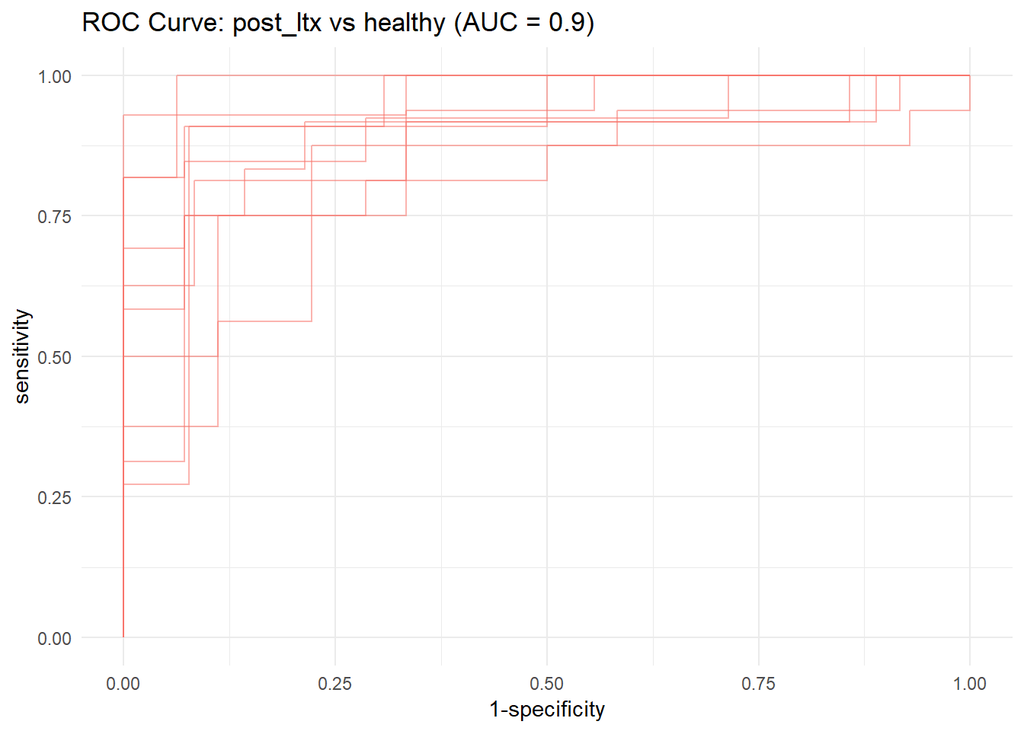

```r
roc_c
```

##### kNN

###### ASV level

```r
level="ASV"
```

*pre_ltx vs healthy*

```r
group <- c("pre_ltx","healthy")
comparison_name <- paste0(group[1], " vs ",group[2])
```

```r
model_name <- paste(comparison_name,level,segment)

# prepare the data
filt_ileum_uni_data <- binomial_prep(ileum_asv_tab,
                                     ileum_taxa_tab,
                                     ileum_metadata,
                                     group, usage="ml_ra")
```

```
## Removing 532 ASV(s)
```

```
## Removing 83 ASV(s)
```

```r
# fit the model
knn_model <- knn_binomial(filt_ileum_uni_data,
                              sample_method = "atypboot",
                              outcome="Group",
                              N=10,
                              reuse=TRUE,
                              file=model_name,
                              Q="Q1_norway")

# ROC curve
roc_c <- roc_curve(knn_model, group)
# save the results
supplements_models[["models_summ"]][["knn_model_ra"]][[model_name]] <- knn_model$model_summary

supplements_models[["roc_cs"]][["knn_model_ra"]][[model_name]] <- knn_model$kfold_rocobjs

# see the results
knn_model$model_summary %>% t()
```

```
##                                       [,1]
## k                               14.0000000
## auc                              0.9528986
## auc_optimism_corrected           0.8916886
## auc_optimism_corrected_CIL       0.8212784
## auc_optimism_corrected_CIU       0.9415814
## accuracy                         0.8292683
## accuracy_optimism_corrected      0.7000703
## accuracy_optimism_corrected_CIL  0.6206897
## accuracy_optimism_corrected_CIU  0.8059615
```

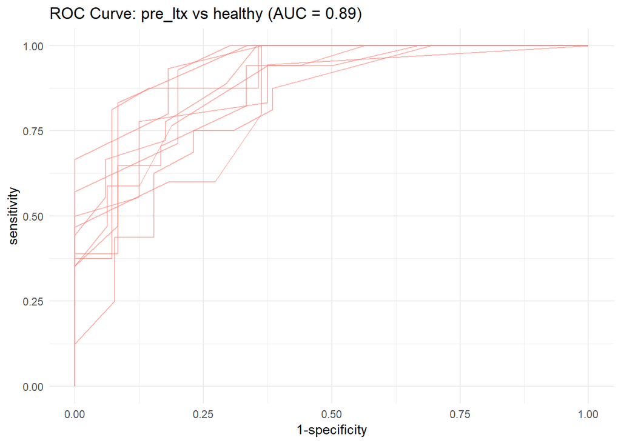

```r
roc_c
```

**pre_ltx vs post_ltx**

```r
group <- c("pre_ltx","post_ltx")
comparison_name <- paste0(group[1], " vs ",group[2])
```

```r
model_name <- paste(comparison_name,level,segment)

# prepare the data
filt_ileum_uni_data <- binomial_prep(ileum_asv_tab,
                                     ileum_taxa_tab,
                                     ileum_metadata,
                                     group, usage="ml_ra")
```

```
## Removing 798 ASV(s)
```

```
## Removing 48 ASV(s)
```

```r
# fit the model
knn_model <- knn_binomial(filt_ileum_uni_data,
                              sample_method = "atypboot",
                              outcome="Group",
                              N=10,
                              reuse=TRUE,
                              file=model_name,
                              Q="Q1_norway")

# ROC curve
roc_c <- roc_curve(knn_model, group)
# save the results
supplements_models[["models_summ"]][["knn_model_ra"]][[model_name]] <- knn_model$model_summary

supplements_models[["roc_cs"]][["knn_model_ra"]][[model_name]] <- knn_model$kfold_rocobjs

# see the results
knn_model$model_summary %>% t()
```

```
##                                       [,1]
## k                               15.0000000
## auc                              0.7213164
## auc_optimism_corrected           0.5957375
## auc_optimism_corrected_CIL       0.5095830
## auc_optimism_corrected_CIU       0.7305672
## accuracy                         0.6585366
## accuracy_optimism_corrected      0.5871462
## accuracy_optimism_corrected_CIL  0.5172414
## accuracy_optimism_corrected_CIU  0.7194056
```

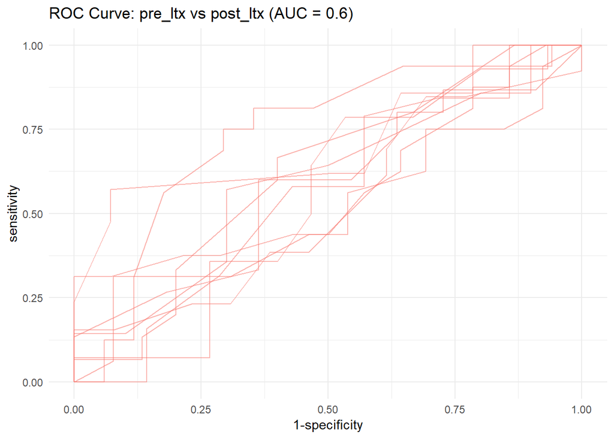

```r
roc_c
```

**post_ltx vs healthy**

```r
group <- c("post_ltx","healthy")
comparison_name <- paste0(group[1], " vs ",group[2])
```

```r
model_name <- paste(comparison_name,level,segment)

# prepare the data
filt_ileum_uni_data <- binomial_prep(ileum_asv_tab,
                                     ileum_taxa_tab,
                                     ileum_metadata,
                                     group, usage="ml_ra")
```

```
## Removing 582 ASV(s)
```

```
## Removing 94 ASV(s)
```

```r
# fit the model
knn_model <- knn_binomial(filt_ileum_uni_data,
                              sample_method = "atypboot",
                              outcome="Group",
                              N=10,
                              reuse=TRUE,
                              file=model_name,
                              Q="Q1_norway")

# ROC curve
roc_c <- roc_curve(knn_model, group)
# save the results
supplements_models[["models_summ"]][["knn_model_ra"]][[model_name]] <- knn_model$model_summary

supplements_models[["roc_cs"]][["knn_model_ra"]][[model_name]] <- knn_model$kfold_rocobjs

# see the results
knn_model$model_summary %>% t()
```

```
##                                       [,1]
## k                               10.0000000
## auc                              0.9347994
## auc_optimism_corrected           0.8689793
## auc_optimism_corrected_CIL       0.7805043
## auc_optimism_corrected_CIU       0.9406064
## accuracy                         0.8055556
## accuracy_optimism_corrected      0.7052182
## accuracy_optimism_corrected_CIL  0.5522500
## accuracy_optimism_corrected_CIU  0.8730769
```

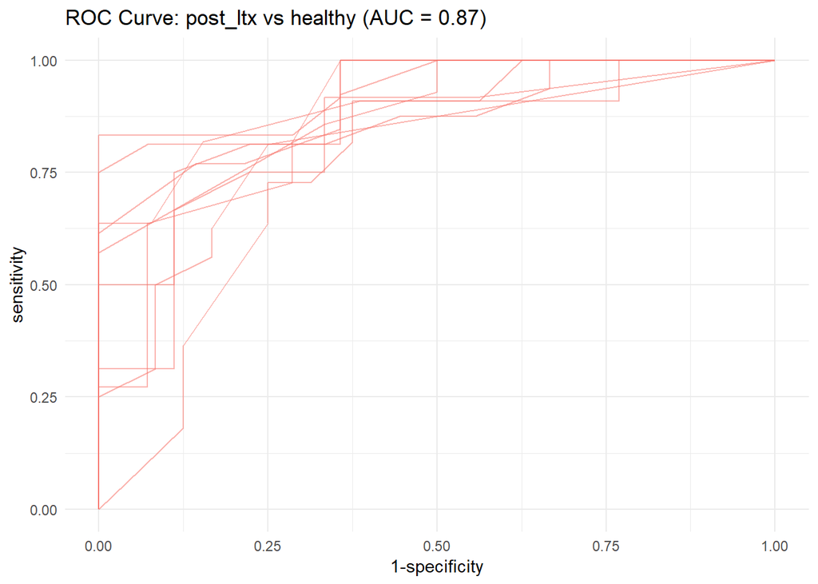

```r
roc_c
```

###### Genus level

```r
level="genus"
```

Aggregate taxa

```r
genus_data <- aggregate_taxa(ileum_asv_tab,
                             ileum_taxa_tab,
                             taxonomic_level = level)

ileum_genus_tab <- genus_data[[1]]
ileum_genus_taxa_tab <- genus_data[[2]]
```

**pre_ltx vs healthy**

```r
group <- c("pre_ltx","healthy")
comparison_name <- paste0(group[1], " vs ",group[2])
```

```r
model_name <- paste(comparison_name,level,segment)

# prepare the data
filt_ileum_uni_data <- binomial_prep(ileum_genus_tab,
                                     ileum_genus_taxa_tab,
                                     ileum_metadata,
                                     group,
                                     usage="ml_ra")
```

```
## Removing 37 ASV(s)
```

```
## Removing 6 ASV(s)
```

```r
# fit the model
knn_model <- knn_binomial(filt_ileum_uni_data,
                              sample_method = "atypboot",
                              outcome="Group",
                              N=10,
                              reuse=TRUE,
                              file=model_name,
                              Q="Q1_norway")

# ROC curve
roc_c <- roc_curve(knn_model, group)
# save the results
supplements_models[["models_summ"]][["knn_model_ra"]][[model_name]] <- knn_model$model_summary

supplements_models[["roc_cs"]][["knn_model_ra"]][[model_name]] <- knn_model$kfold_rocobjs

# see the results
knn_model$model_summary %>% t()
```

```
##                                       [,1]
## k                               13.0000000
## auc                              0.9320652
## auc_optimism_corrected           0.8382346
## auc_optimism_corrected_CIL       0.7049526
## auc_optimism_corrected_CIU       0.9391406
## accuracy                         0.8048780
## accuracy_optimism_corrected      0.6880801
## accuracy_optimism_corrected_CIL  0.5846737
## accuracy_optimism_corrected_CIU  0.7785417
```

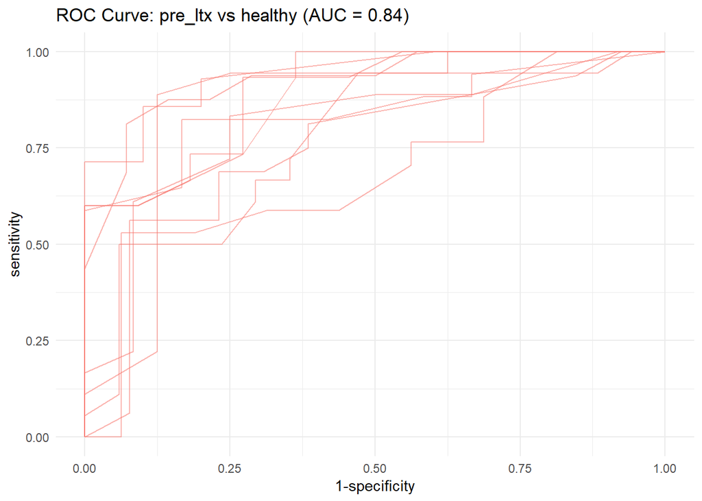

```r
roc_c
```

**pre_ltx vs post_ltx**

```r
group <- c("pre_ltx","post_ltx")
comparison_name <- paste0(group[1], " vs ",group[2])
```

```r
model_name <- paste(comparison_name,level,segment)

# prepare the data
filt_ileum_uni_data <- binomial_prep(ileum_genus_tab,
                                     ileum_genus_taxa_tab,
                                     ileum_metadata,
                                     group,
                                     usage="ml_ra")
```

```
## Removing 30 ASV(s)
```

```
## Removing 5 ASV(s)
```

```r
# fit the model
knn_model <- knn_binomial(filt_ileum_uni_data,
                              sample_method = "atypboot",
                              outcome="Group",
                              N=10,
                              reuse=TRUE,
                              file=model_name,
                              Q="Q1_norway")

# ROC curve
roc_c <- roc_curve(knn_model, group)
# save the results
supplements_models[["models_summ"]][["knn_model_ra"]][[model_name]] <- knn_model$model_summary

supplements_models[["roc_cs"]][["knn_model_ra"]][[model_name]] <- knn_model$kfold_rocobjs

# see the results
knn_model$model_summary %>% t()
```

```
##                                       [,1]
## k                               23.0000000
## auc                              0.6953502
## auc_optimism_corrected           0.5652388
## auc_optimism_corrected_CIL       0.4263759
## auc_optimism_corrected_CIU       0.7115888
## accuracy                         0.6219512
## accuracy_optimism_corrected      0.5487237
## accuracy_optimism_corrected_CIL  0.4599138
## accuracy_optimism_corrected_CIU  0.6132867
```

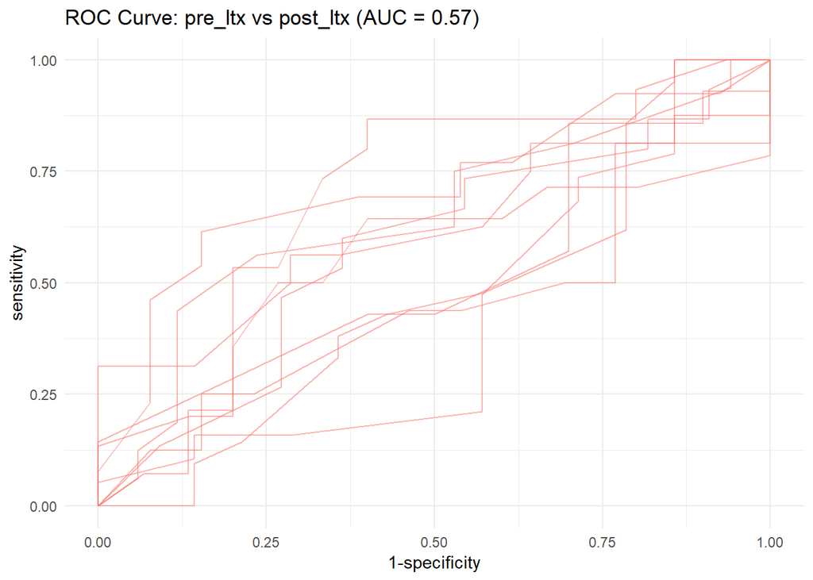

```r
roc_c
```

**post_ltx vs healthy**

```r
group <- c("post_ltx","healthy")
comparison_name <- paste0(group[1], " vs ",group[2])
```

```r
model_name <- paste(comparison_name,level,segment)

# prepare the data
filt_ileum_uni_data <- binomial_prep(ileum_genus_tab,
                                     ileum_genus_taxa_tab,
                                     ileum_metadata,
                                     group,
                                     usage="ml_ra")
```

```
## Removing 53 ASV(s)
```

```
## Removing 5 ASV(s)
```

```r
# fit the model
knn_model <- knn_binomial(filt_ileum_uni_data,
                              sample_method = "atypboot",
                              outcome="Group",
                              N=10,
                              reuse=TRUE,
                              file=model_name,
                              Q="Q1_norway")

# ROC curve
roc_c <- roc_curve(knn_model, group)
# save the results
supplements_models[["models_summ"]][["knn_model_ra"]][[model_name]] <- knn_model$model_summary

supplements_models[["roc_cs"]][["knn_model_ra"]][[model_name]] <- knn_model$kfold_rocobjs

# see the results
knn_model$model_summary %>% t()
```

```
##                                       [,1]
## k                               10.0000000
## auc                              0.9116512
## auc_optimism_corrected           0.8182651
## auc_optimism_corrected_CIL       0.7459353
## auc_optimism_corrected_CIU       0.8999087
## accuracy                         0.7916667
## accuracy_optimism_corrected      0.6976268
## accuracy_optimism_corrected_CIL  0.5868571
## accuracy_optimism_corrected_CIU  0.8550769
```

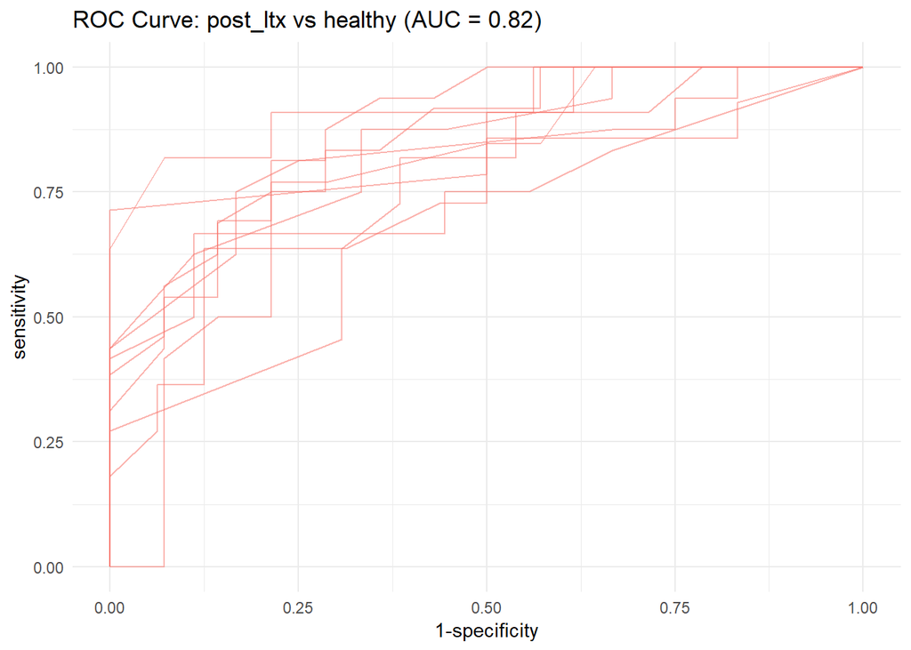

```r
roc_c
```

##### Random Forest

###### ASV level

```r
level="ASV"
```

*pre_ltx vs healthy*

```r
group <- c("pre_ltx","healthy")
comparison_name <- paste0(group[1], " vs ",group[2])
```

```r
model_name <- paste(comparison_name,level,segment)

# prepare the data
filt_ileum_uni_data <- binomial_prep(ileum_asv_tab,
                                     ileum_taxa_tab,
                                     ileum_metadata,
                                     group, usage="ml_ra")
```

```
## Removing 532 ASV(s)
```

```
## Removing 83 ASV(s)
```

```r
# fit the model
rf_model <- rf_binomial(filt_ileum_uni_data,
                              sample_method = "atypboot",
                              outcome="Group",
                              N=10,
                              reuse=TRUE,
                              file=model_name,
                              Q="Q1_norway")

# ROC curve
roc_c <- roc_curve(rf_model, group)
# save the results
supplements_models[["models_summ"]][["rf_model_ra"]][[model_name]] <- rf_model$model_summary

supplements_models[["roc_cs"]][["rf_model_ra"]][[model_name]] <- rf_model$kfold_rocobjs

# see the results
rf_model$model_summary %>% t()
```

```
##                                 [,1]
## mtry                            "17"
## splitrule                       "gini"
## min.node.size                   "2"
## auc                             "1"
## auc_optimism_corrected          "0.9847369"
## auc_optimism_corrected_CIL      "0.9549794"
## auc_optimism_corrected_CIU      "1"
## accuracy                        "1"
## accuracy_optimism_corrected     "0.9214891"
## accuracy_optimism_corrected_CIL "0.8534965"
## accuracy_optimism_corrected_CIU "0.9925"
```

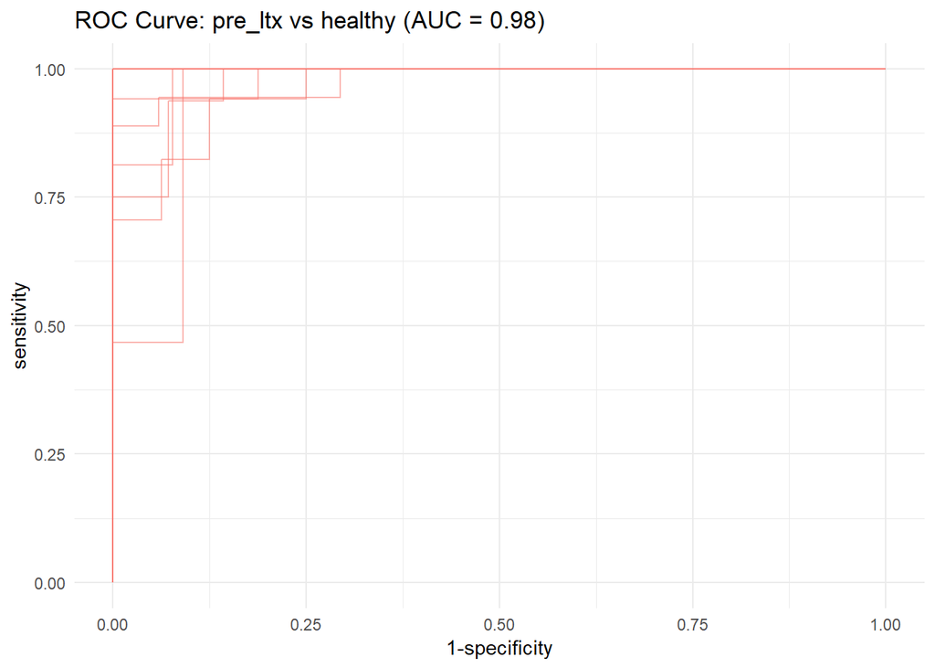

```r
roc_c
```

**pre_ltx vs post_ltx**

```r
group <- c("pre_ltx","post_ltx")
comparison_name <- paste0(group[1], " vs ",group[2])
```

```r
model_name <- paste(comparison_name,level,segment)

# prepare the data
filt_ileum_uni_data <- binomial_prep(ileum_asv_tab,
                                     ileum_taxa_tab,
                                     ileum_metadata,
                                     group, usage="ml_ra")
```

```
## Removing 798 ASV(s)
```

```
## Removing 48 ASV(s)
```

```r
# fit the model
rf_model <- rf_binomial(filt_ileum_uni_data,
                              sample_method = "atypboot",
                              outcome="Group",
                              N=10,
                              reuse=TRUE,
                              file=model_name,
                              Q="Q1_norway")

# ROC curve
roc_c <- roc_curve(rf_model, group)
# save the results
supplements_models[["models_summ"]][["rf_model_ra"]][[model_name]] <- rf_model$model_summary

supplements_models[["roc_cs"]][["rf_model_ra"]][[model_name]] <- rf_model$kfold_rocobjs


# see the results
rf_model$model_summary %>% t()
```

```
##                                 [,1]
## mtry                            "145"
## splitrule                       "gini"
## min.node.size                   "5"
## auc                             "1"
## auc_optimism_corrected          "0.9643818"
## auc_optimism_corrected_CIL      "0.9189681"
## auc_optimism_corrected_CIU      "0.9960793"
## accuracy                        "1"
## accuracy_optimism_corrected     "0.896525"
## accuracy_optimism_corrected_CIL "0.7923368"
## accuracy_optimism_corrected_CIU "0.9655172"
```

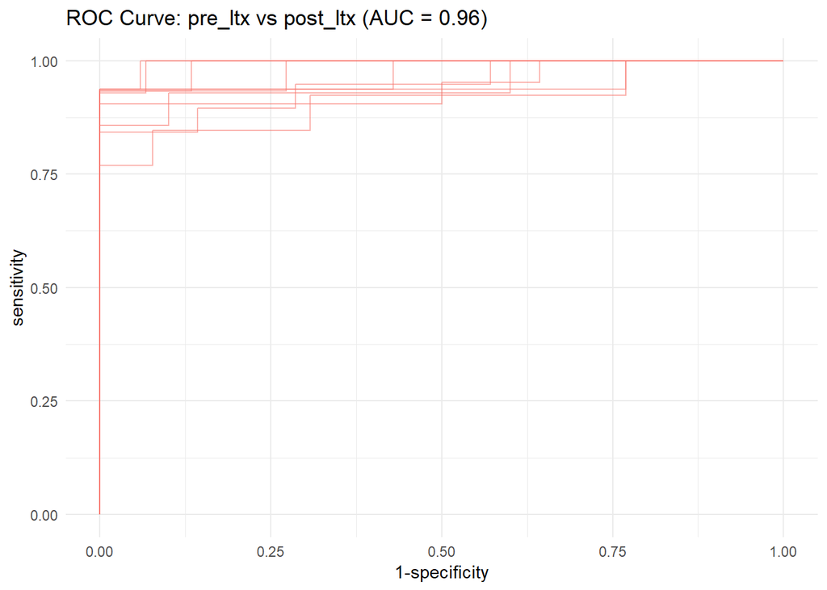

```r
roc_c
```

**post_ltx vs healthy**

```r
group <- c("post_ltx","healthy")
comparison_name <- paste0(group[1], " vs ",group[2])
```

```r
model_name <- paste(comparison_name,level,segment)

# prepare the data
filt_ileum_uni_data <- binomial_prep(ileum_asv_tab,
                                     ileum_taxa_tab,
                                     ileum_metadata,
                                     group, usage="ml_ra")
```

```
## Removing 582 ASV(s)
```

```
## Removing 94 ASV(s)
```

```r
# fit the model
rf_model <- rf_binomial(filt_ileum_uni_data,
                              sample_method = "atypboot",
                              outcome="Group",
                              N=10,
                              reuse=TRUE,
                              file=model_name,
                              Q="Q1_norway")

# ROC curve
roc_c <- roc_curve(rf_model, group)
# save the results
supplements_models[["models_summ"]][["rf_model_ra"]][[model_name]] <- rf_model$model_summary

supplements_models[["roc_cs"]][["rf_model_ra"]][[model_name]] <- rf_model$kfold_rocobjs


# see the results
rf_model$model_summary %>% t()
```

```
##                                 [,1]
## mtry                            "43"
## splitrule                       "gini"
## min.node.size                   "2"
## auc                             "1"
## auc_optimism_corrected          "0.9058463"
## auc_optimism_corrected_CIL      "0.7945391"
## auc_optimism_corrected_CIU      "0.998539"
## accuracy                        "1"
## accuracy_optimism_corrected     "0.8109699"
## accuracy_optimism_corrected_CIL "0.6936667"
## accuracy_optimism_corrected_CIU "0.9356667"
```

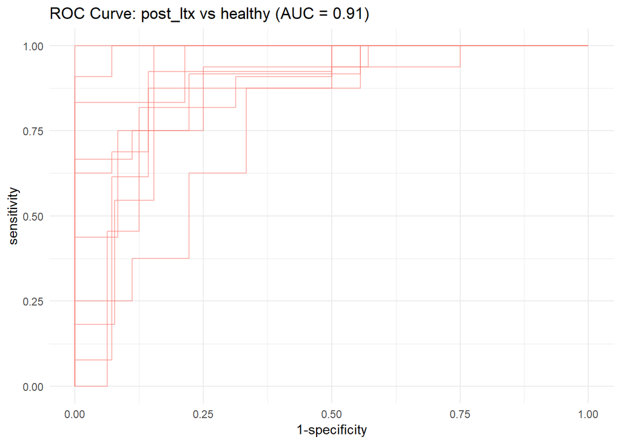

```r
roc_c
```

###### Genus level

```r
level="genus"
```

Aggregate taxa

```r
genus_data <- aggregate_taxa(ileum_asv_tab,
                             ileum_taxa_tab,
                             taxonomic_level = level)

ileum_genus_tab <- genus_data[[1]]
ileum_genus_taxa_tab <- genus_data[[2]]
```

**pre_ltx vs healthy**

```r
group <- c("pre_ltx","healthy")
comparison_name <- paste0(group[1], " vs ",group[2])
```

```r
model_name <- paste(comparison_name,level,segment)

# prepare the data
filt_ileum_uni_data <- binomial_prep(ileum_genus_tab,
                                     ileum_genus_taxa_tab,
                                     ileum_metadata,
                                     group,
                                     usage="ml_ra")
```

```
## Removing 37 ASV(s)
```

```
## Removing 6 ASV(s)
```

```r
# fit the model
rf_model <- rf_binomial(filt_ileum_uni_data,
                              sample_method = "atypboot",
                              outcome="Group",
                              N=10,
                              reuse=TRUE,
                              file=model_name,
                              Q="Q1_norway")

# ROC curve
roc_c <- roc_curve(rf_model, group)
# save the results
supplements_models[["models_summ"]][["rf_model_ra"]][[model_name]] <- rf_model$model_summary

supplements_models[["roc_cs"]][["rf_model_ra"]][[model_name]] <- rf_model$kfold_rocobjs


# see the results
rf_model$model_summary %>% t()
```

```
##                                 [,1]
## mtry                            "35"
## splitrule                       "gini"
## min.node.size                   "2"
## auc                             "1"
## auc_optimism_corrected          "0.9653117"
## auc_optimism_corrected_CIL      "0.8524706"
## auc_optimism_corrected_CIU      "1"
## accuracy                        "1"
## accuracy_optimism_corrected     "0.8969094"
## accuracy_optimism_corrected_CIL "0.7603117"
## accuracy_optimism_corrected_CIU "0.9935714"
```

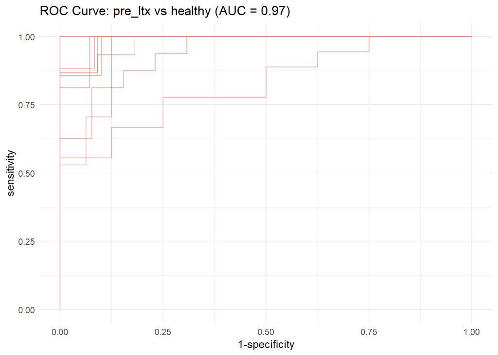

```r
roc_c
```

**pre_ltx vs post_ltx**

```r
group <- c("pre_ltx","post_ltx")
comparison_name <- paste0(group[1], " vs ",group[2])
```

```r
model_name <- paste(comparison_name,level,segment)

# prepare the data
filt_ileum_uni_data <- binomial_prep(ileum_genus_tab,
                                     ileum_genus_taxa_tab,
                                     ileum_metadata,
                                     group,
                                     usage="ml_ra")
```

```
## Removing 30 ASV(s)
```

```
## Removing 5 ASV(s)
```

```r
# fit the model
rf_model <- rf_binomial(filt_ileum_uni_data,
                              sample_method = "atypboot",
                              outcome="Group",
                              N=10,
                              reuse=TRUE,
                              file=model_name,
                              Q="Q1_norway")

# ROC curve
roc_c <- roc_curve(rf_model, group)
# save the results
supplements_models[["models_summ"]][["rf_model_ra"]][[model_name]] <- rf_model$model_summary

supplements_models[["roc_cs"]][["rf_model_ra"]][[model_name]] <- rf_model$kfold_rocobjs


# see the results
rf_model$model_summary %>% t()
```

```
##                                 [,1]
## mtry                            "117"
## splitrule                       "gini"
## min.node.size                   "2"
## auc                             "1"
## auc_optimism_corrected          "0.9743134"
## auc_optimism_corrected_CIL      "0.9426692"
## auc_optimism_corrected_CIU      "1"
## accuracy                        "1"
## accuracy_optimism_corrected     "0.8932112"
## accuracy_optimism_corrected_CIL "0.7743596"
## accuracy_optimism_corrected_CIU "0.9605303"
```

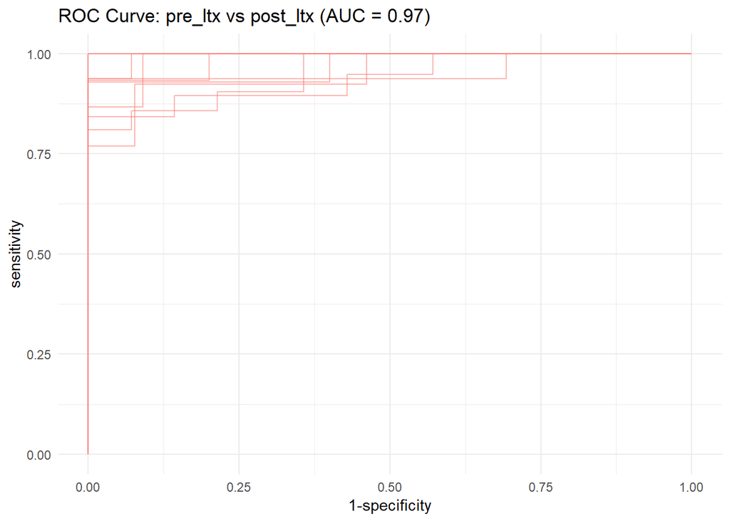

```r
roc_c
```

**post_ltx vs healthy**

```r
group <- c("post_ltx","healthy")
comparison_name <- paste0(group[1], " vs ",group[2])
```

```r
model_name <- paste(comparison_name,level,segment)

# prepare the data
filt_ileum_uni_data <- binomial_prep(ileum_genus_tab,
                                     ileum_genus_taxa_tab,
                                     ileum_metadata,
                                     group,
                                     usage="ml_ra")
```

```
## Removing 53 ASV(s)
```

```
## Removing 5 ASV(s)
```

```r
# fit the model
rf_model <- rf_binomial(filt_ileum_uni_data,
                              sample_method = "atypboot",
                              outcome="Group",
                              N=10,
                              reuse=TRUE,
                              file=model_name,
                              Q="Q1_norway")

# ROC curve
roc_c <- roc_curve(rf_model, group)
# save the results
supplements_models[["models_summ"]][["rf_model_ra"]][[model_name]] <- rf_model$model_summary

supplements_models[["roc_cs"]][["rf_model_ra"]][[model_name]] <- rf_model$kfold_rocobjs


# see the results
rf_model$model_summary %>% t()
```

```
##                                 [,1]
## mtry                            "19"
## splitrule                       "gini"
## min.node.size                   "2"
## auc                             "1"
## auc_optimism_corrected          "0.9438023"
## auc_optimism_corrected_CIL      "0.8844602"
## auc_optimism_corrected_CIU      "0.9973214"
## accuracy                        "1"
## accuracy_optimism_corrected     "0.8638447"
## accuracy_optimism_corrected_CIL "0.8021429"
## accuracy_optimism_corrected_CIU "0.9223846"
```

```r
roc_c
```

##### Gradient boosting

###### ASV level

```r
level="ASV"
```

*pre_ltx vs healthy*

```r
group <- c("pre_ltx","healthy")
comparison_name <- paste0(group[1], " vs ",group[2])
```

```r
model_name <- paste(comparison_name,level,segment)

# prepare the data
filt_ileum_uni_data <- binomial_prep(ileum_asv_tab,
                                     ileum_taxa_tab,
                                     ileum_metadata,
                                     group, usage="ml_ra")
```

```
## Removing 532 ASV(s)
```

```
## Removing 83 ASV(s)
```

```r
# fit the model
gbm_model <- gbm_binomial(filt_ileum_uni_data,
                              sample_method = "atypboot",
                              outcome="Group",
                              N=10,
                              reuse=TRUE,
                              file=model_name,
                              Q="Q1_norway")

# ROC curve
roc_c <- roc_curve(gbm_model, group)
# save the results
supplements_models[["models_summ"]][["gbm_model_ra"]][[model_name]] <- gbm_model$model_summary

supplements_models[["roc_cs"]][["gbm_model_ra"]][[model_name]] <- gbm_model$kfold_rocobjs

# see the results
gbm_model$model_summary %>% t()
```

```
##                                 [,1]
## mtry                            "19"
## splitrule                       "gini"
## min.node.size                   "2"
## auc                             "1"
## auc_optimism_corrected          "0.9438023"
## auc_optimism_corrected_CIL      "0.8844602"
## auc_optimism_corrected_CIU      "0.9973214"
## accuracy                        "1"
## accuracy_optimism_corrected     "0.8638447"
## accuracy_optimism_corrected_CIL "0.8021429"
## accuracy_optimism_corrected_CIU "0.9223846"
```

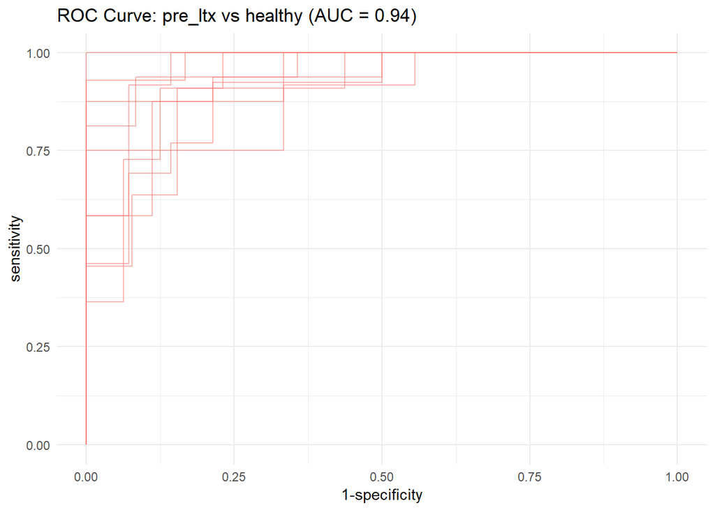

```r
roc_c
```

**pre_ltx vs post_ltx**

```r
group <- c("pre_ltx","post_ltx")
comparison_name <- paste0(group[1], " vs ",group[2])
```

```r
model_name <- paste(comparison_name,level,segment)

# prepare the data
filt_ileum_uni_data <- binomial_prep(ileum_asv_tab,
                                     ileum_taxa_tab,
                                     ileum_metadata,
                                     group, usage="ml_ra")
```

```
## Removing 798 ASV(s)
```

```
## Removing 48 ASV(s)
```

```r
# fit the model
gbm_model <- gbm_binomial(filt_ileum_uni_data,
                              sample_method = "atypboot",
                              outcome="Group",
                              N=10,
                              reuse=TRUE,
                              file=model_name,
                              Q="Q1_norway")

# ROC curve
roc_c <- roc_curve(gbm_model, group)
# save the results
supplements_models[["models_summ"]][["gbm_model_ra"]][[model_name]] <- gbm_model$model_summary

supplements_models[["roc_cs"]][["gbm_model_ra"]][[model_name]] <- gbm_model$kfold_rocobjs

# see the results
gbm_model$model_summary %>% t()
```

```
##                                 [,1]
## mtry                            "19"
## splitrule                       "gini"
## min.node.size                   "2"
## auc                             "1"
## auc_optimism_corrected          "0.9438023"
## auc_optimism_corrected_CIL      "0.8844602"
## auc_optimism_corrected_CIU      "0.9973214"
## accuracy                        "1"
## accuracy_optimism_corrected     "0.8638447"
## accuracy_optimism_corrected_CIL "0.8021429"
## accuracy_optimism_corrected_CIU "0.9223846"
```

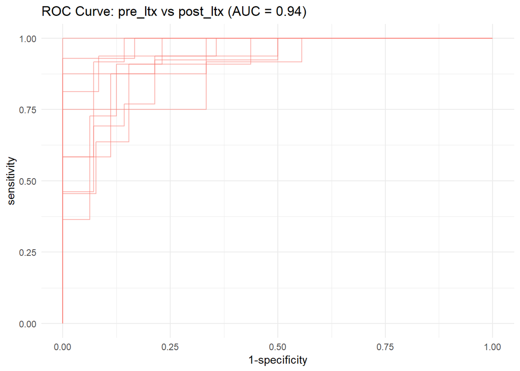

```r
roc_c
```

**post_ltx vs healthy**

```r
group <- c("post_ltx","healthy")
comparison_name <- paste0(group[1], " vs ",group[2])
```

```r
model_name <- paste(comparison_name,level,segment)

# prepare the data
filt_ileum_uni_data <- binomial_prep(ileum_asv_tab,
                                     ileum_taxa_tab,
                                     ileum_metadata,
                                     group, usage="ml_ra")
```

```
## Removing 582 ASV(s)
```

```
## Removing 94 ASV(s)
```

```r
# fit the model
gbm_model <- gbm_binomial(filt_ileum_uni_data,
                              sample_method = "atypboot",
                              outcome="Group",
                              N=10,
                              reuse=TRUE,
                              file=model_name,
                              Q="Q1_norway")

# ROC curve
roc_c <- roc_curve(gbm_model, group)
# save the results
supplements_models[["models_summ"]][["gbm_model_ra"]][[model_name]] <- gbm_model$model_summary

supplements_models[["roc_cs"]][["gbm_model_ra"]][[model_name]] <- gbm_model$kfold_rocobjs

# see the results
gbm_model$model_summary %>% t()
```

```
##                                 [,1]
## mtry                            "19"
## splitrule                       "gini"
## min.node.size                   "2"
## auc                             "1"
## auc_optimism_corrected          "0.9438023"
## auc_optimism_corrected_CIL      "0.8844602"
## auc_optimism_corrected_CIU      "0.9973214"
## accuracy                        "1"
## accuracy_optimism_corrected     "0.8638447"
## accuracy_optimism_corrected_CIL "0.8021429"
## accuracy_optimism_corrected_CIU "0.9223846"
```

```r
roc_c
```

###### Genus level

```r
level="genus"
```

Aggregate taxa

```r
genus_data <- aggregate_taxa(ileum_asv_tab,
                             ileum_taxa_tab,
                             taxonomic_level = level)

ileum_genus_tab <- genus_data[[1]]
ileum_genus_taxa_tab <- genus_data[[2]]
```

**pre_ltx vs healthy**

```r
group <- c("pre_ltx","healthy")
comparison_name <- paste0(group[1], " vs ",group[2])
```

```r
model_name <- paste(comparison_name,level,segment)

# prepare the data
filt_ileum_uni_data <- binomial_prep(ileum_genus_tab,
                                     ileum_genus_taxa_tab,
                                     ileum_metadata,
                                     group,
                                     usage="ml_ra")
```

```
## Removing 37 ASV(s)
```

```
## Removing 6 ASV(s)
```

```r
# fit the model
gbm_model <- gbm_binomial(filt_ileum_uni_data,
                              sample_method = "atypboot",
                              outcome="Group",
                              N=10,
                              reuse=TRUE,
                              file=model_name,
                              Q="Q1_norway")

# ROC curve
roc_c <- roc_curve(gbm_model, group)
# save the results
supplements_models[["models_summ"]][["gbm_model_ra"]][[model_name]] <- gbm_model$model_summary

supplements_models[["roc_cs"]][["gbm_model_ra"]][[model_name]] <- gbm_model$kfold_rocobjs

# see the results
gbm_model$model_summary %>% t()
```

```
##                                 [,1]
## mtry                            "19"
## splitrule                       "gini"
## min.node.size                   "2"
## auc                             "1"
## auc_optimism_corrected          "0.9438023"
## auc_optimism_corrected_CIL      "0.8844602"
## auc_optimism_corrected_CIU      "0.9973214"
## accuracy                        "1"
## accuracy_optimism_corrected     "0.8638447"
## accuracy_optimism_corrected_CIL "0.8021429"
## accuracy_optimism_corrected_CIU "0.9223846"
```

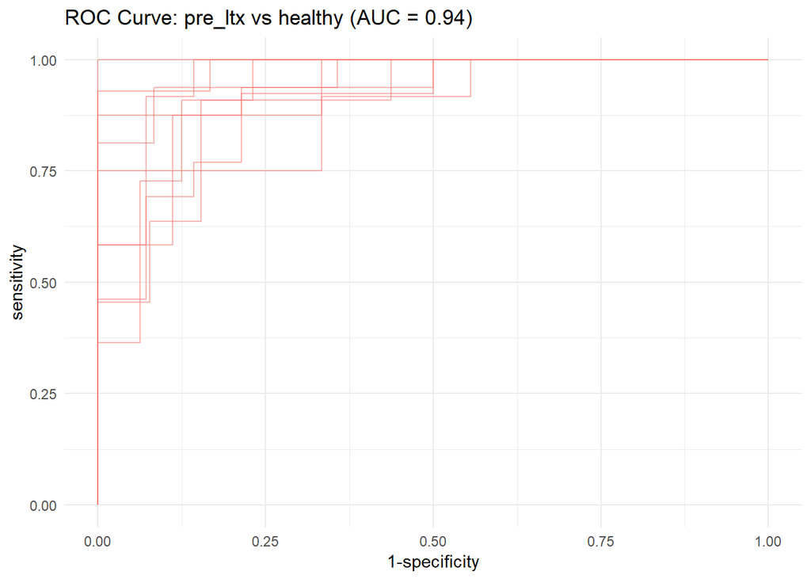

```r
roc_c
```

**pre_ltx vs post_ltx**

```r
group <- c("pre_ltx","post_ltx")
comparison_name <- paste0(group[1], " vs ",group[2])
```

```r
model_name <- paste(comparison_name,level,segment)

# prepare the data
filt_ileum_uni_data <- binomial_prep(ileum_genus_tab,
                                     ileum_genus_taxa_tab,
                                     ileum_metadata,
                                     group,
                                     usage="ml_ra")
```

```
## Removing 30 ASV(s)
```

```
## Removing 5 ASV(s)
```

```r
# fit the model
gbm_model <- gbm_binomial(filt_ileum_uni_data,
                              sample_method = "atypboot",
                              outcome="Group",
                              N=10,
                              reuse=TRUE,
                              file=model_name,
                              Q="Q1_norway")

# ROC curve
roc_c <- roc_curve(gbm_model, group)
# save the results
supplements_models[["models_summ"]][["gbm_model_ra"]][[model_name]] <- gbm_model$model_summary

supplements_models[["roc_cs"]][["gbm_model_ra"]][[model_name]] <- gbm_model$kfold_rocobjs

# see the results
gbm_model$model_summary %>% t()
```

```
##                                 [,1]
## mtry                            "19"
## splitrule                       "gini"
## min.node.size                   "2"
## auc                             "1"
## auc_optimism_corrected          "0.9438023"
## auc_optimism_corrected_CIL      "0.8844602"
## auc_optimism_corrected_CIU      "0.9973214"
## accuracy                        "1"
## accuracy_optimism_corrected     "0.8638447"
## accuracy_optimism_corrected_CIL "0.8021429"
## accuracy_optimism_corrected_CIU "0.9223846"
```

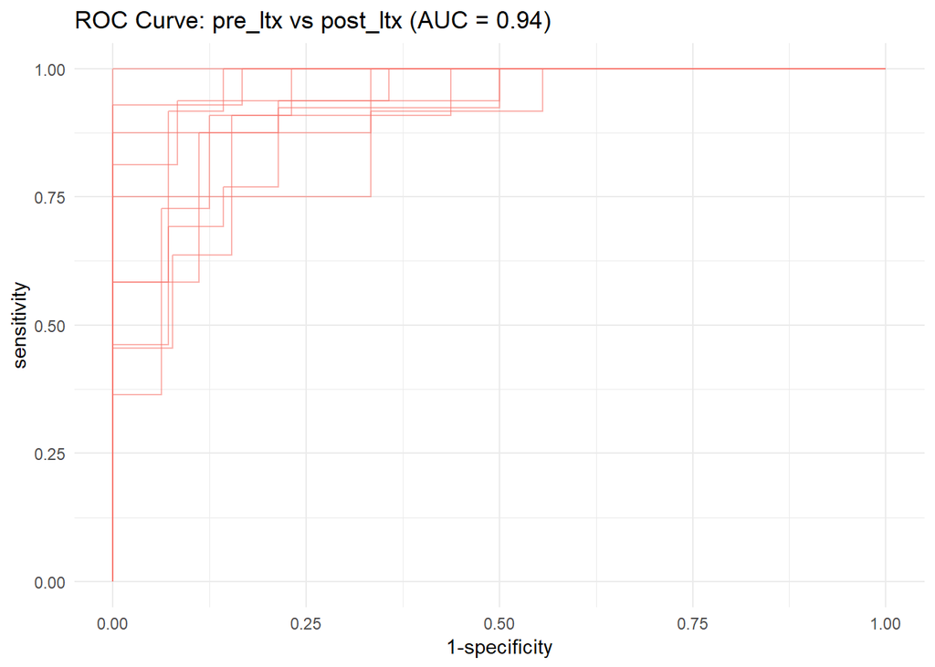

```r
roc_c
```

**post_ltx vs healthy**

```r
group <- c("post_ltx","healthy")
comparison_name <- paste0(group[1], " vs ",group[2])
```

```r
model_name <- paste(comparison_name,level,segment)

# prepare the data
filt_ileum_uni_data <- binomial_prep(ileum_genus_tab,
                                     ileum_genus_taxa_tab,
                                     ileum_metadata,
                                     group,
                                     usage="ml_ra")
```

```
## Removing 53 ASV(s)
```

```
## Removing 5 ASV(s)
```

```r
# fit the model
gbm_model <- gbm_binomial(filt_ileum_uni_data,
                              sample_method = "atypboot",
                              outcome="Group",
                              N=10,
                              reuse=TRUE,
                              file=model_name,
                              Q="Q1_norway")

# ROC curve
roc_c <- roc_curve(gbm_model, group)
# save the results
supplements_models[["models_summ"]][["gbm_model_ra"]][[model_name]] <- gbm_model$model_summary

supplements_models[["roc_cs"]][["gbm_model_ra"]][[model_name]] <- gbm_model$kfold_rocobjs

# see the results
gbm_model$model_summary %>% t()
```

```
##                                 [,1]
## mtry                            "19"
## splitrule                       "gini"
## min.node.size                   "2"
## auc                             "1"
## auc_optimism_corrected          "0.9438023"
## auc_optimism_corrected_CIL      "0.8844602"
## auc_optimism_corrected_CIU      "0.9973214"
## accuracy                        "1"
## accuracy_optimism_corrected     "0.8638447"
## accuracy_optimism_corrected_CIL "0.8021429"
## accuracy_optimism_corrected_CIU "0.9223846"
```

```r
roc_c
```

#### Saving results

```r
models_list <- list()

for (model_name in names(supplements_models$models_summ)){
  df <- do.call(rbind, supplements_models$models_summ[[model_name]])
  models_list[[model_name]] <- df
}

write.xlsx(models_list,
           file=file.path(path,paste0("supplements_models_",segment,".xlsx")),
           rowNames=TRUE)
```

## Results overview

#### Alpha diversity

```r
pc_observed[[segment]]
```

|  | Estimate | Std..Error | t.value | Pr...t.. | p.adj | sig |
| --- | --- | --- | --- | --- | --- | --- |
| healthy vs Grouppre_ltx | -48.135266 | 9.159296 | -5.2553455 | 1.197497e-06 | 3.592491e-06 | *** |
| pre_ltx vs Grouppost_ltx | -9.614734 | 10.544637 | -0.9118127 | 3.646068e-01 | 3.646068e-01 |  |
| healthy vs Grouppost_ltx | -57.750000 | 11.334075 | -5.0952546 | 2.829706e-06 | 4.244559e-06 | *** |

```r
pc_shannon[[segment]]
```

|  | Estimate | Std..Error | t.value | Pr...t.. | p.adj | sig |
| --- | --- | --- | --- | --- | --- | --- |
| healthy vs Grouppre_ltx | -0.3634736 | 0.1247910 | -2.9126581 | 0.004643215 | 0.006964822 | ** |
| pre_ltx vs Grouppost_ltx | -0.1283093 | 0.1458462 | -0.8797579 | 0.381625561 | 0.381625561 |  |
| healthy vs Grouppost_ltx | -0.4917829 | 0.1396872 | -3.5206005 | 0.000761977 | 0.002285931 | ** |

```r
pc_simpson[[segment]]
```

|  | Estimate | Std..Error | t.value | Pr...t.. | p.adj | sig |
| --- | --- | --- | --- | --- | --- | --- |
| healthy vs Grouppre_ltx | -0.01931143 | 0.01482211 | -1.302880 | 0.19635346 | 0.2606277 |  |
| pre_ltx vs Grouppost_ltx | -0.02312293 | 0.02040984 | -1.132930 | 0.26062767 | 0.2606277 |  |
| healthy vs Grouppost_ltx | -0.04243436 | 0.01987134 | -2.135456 | 0.03622441 | 0.1086732 |  |

```r
pc_pielou[[segment]]
```

|  | Estimate | Std..Error | t.value | Pr...t.. | p.adj | sig |
| --- | --- | --- | --- | --- | --- | --- |
| healthy vs Grouppre_ltx | -0.02960507 | 0.01937301 | -1.5281611 | 0.13041697 | 0.1956255 |  |
| pre_ltx vs Grouppost_ltx | -0.01007350 | 0.02180469 | -0.4619877 | 0.64534409 | 0.6453441 |  |
| healthy vs Grouppost_ltx | -0.03967857 | 0.02031910 | -1.9527717 | 0.05484588 | 0.1645376 |  |

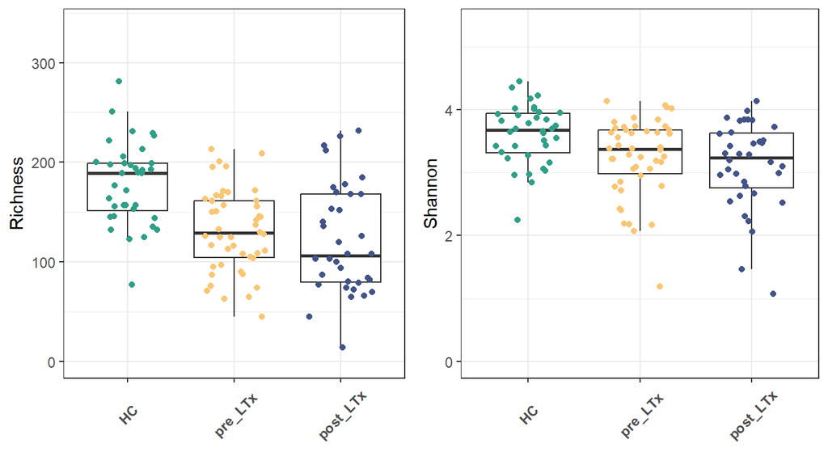

```r
alpha_div_plots[[paste(segment,"Custom")]]
```

#### Beta diversity

**Main results**

```r
pairwise_aitchison_raw[[paste("genus", segment)]]
```

| pairs | Df | SumsOfSqs | F.Model | R2 | p.value | p.adjusted | sig |
| --- | --- | --- | --- | --- | --- | --- | --- |
| pre_ltx vs healthy | 1 | 655.2529 | 3.823776 | 0.04561684 | 0.001 | 0.001 | *** |
| pre_ltx vs post_ltx | 1 | 369.4823 | 2.091702 | 0.02548007 | 0.001 | 0.001 | *** |
| post_ltx vs healthy | 1 | 646.4981 | 3.916027 | 0.05297940 | 0.001 | 0.001 | *** |

PCA

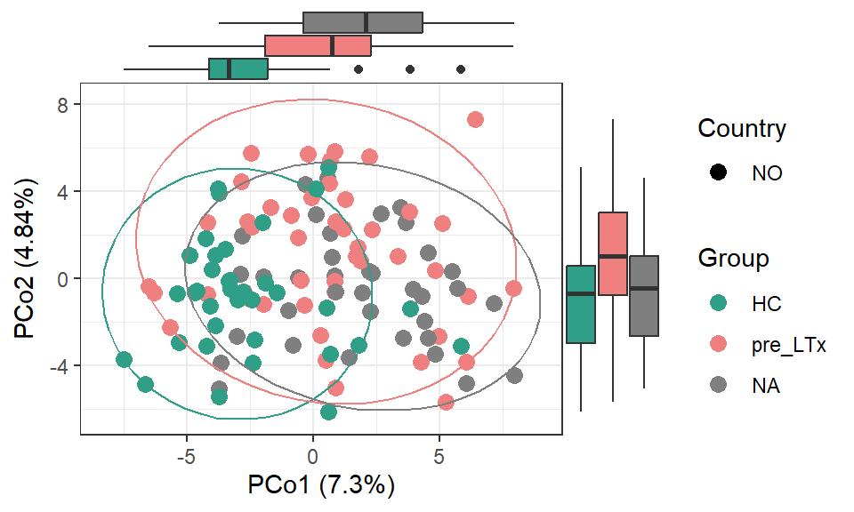

```r
pca_plots_list[[paste(segment,"genus custom")]]
```

**Supplements**

```r
knitr::kable(supplements_beta[!grepl("PCoA",names(supplements_beta))],
             digits = 3,
             caption = "Supplementary PERMANOVA results")
```

Supplementary PERMANOVA results

| pairs | Df | SumsOfSqs | F.Model | R2 | p.value | p.adjusted | sig |
| --- | --- | --- | --- | --- | --- | --- | --- |
| pre_ltx vs healthy | 1 | 1.000 | 5.257 | 0.062 | 0.001 | 0.002 | ** |
| pre_ltx vs post_ltx | 1 | 0.442 | 2.053 | 0.025 | 0.011 | 0.011 | * |
| post_ltx vs healthy | 1 | 1.165 | 6.012 | 0.079 | 0.001 | 0.002 | ** |

| pairs | Df | SumsOfSqs | F.Model | R2 | p.value | p.adjusted | sig |
| --- | --- | --- | --- | --- | --- | --- | --- |
| pre_ltx vs healthy | 1 | 1.114 | 4.010 | 0.048 | 0.001 | 0.002 | ** |
| pre_ltx vs post_ltx | 1 | 0.512 | 1.694 | 0.021 | 0.013 | 0.013 | * |
| post_ltx vs healthy | 1 | 1.225 | 4.313 | 0.058 | 0.001 | 0.002 | ** |

| pairs | Df | SumsOfSqs | F.Model | R2 | p.value | p.adjusted | sig |
| --- | --- | --- | --- | --- | --- | --- | --- |
| pre_ltx vs healthy | 1 | 1022.375 | 3.249 | 0.039 | 0.001 | 0.001 | *** |
| pre_ltx vs post_ltx | 1 | 500.838 | 1.753 | 0.021 | 0.001 | 0.001 | *** |
| post_ltx vs healthy | 1 | 975.120 | 3.241 | 0.044 | 0.001 | 0.001 | *** |

| pairs | Df | SumsOfSqs | F.Model | R2 | p.value | p.adjusted | sig |
| --- | --- | --- | --- | --- | --- | --- | --- |
| pre_ltx vs healthy | 1 | 1.502 | 4.843 | 0.057 | 0.001 | 0.002 | ** |
| pre_ltx vs post_ltx | 1 | 0.648 | 1.964 | 0.024 | 0.004 | 0.004 | ** |
| post_ltx vs healthy | 1 | 1.599 | 5.137 | 0.068 | 0.001 | 0.002 | ** |

| pairs | Df | SumsOfSqs | F.Model | R2 | p.value | p.adjusted | sig |
| --- | --- | --- | --- | --- | --- | --- | --- |
| pre_ltx vs healthy | 1 | 1.275 | 3.334 | 0.040 | 0.001 | 0.002 | ** |
| pre_ltx vs post_ltx | 1 | 0.626 | 1.579 | 0.019 | 0.003 | 0.003 | ** |
| post_ltx vs healthy | 1 | 1.319 | 3.438 | 0.047 | 0.001 | 0.002 | ** |

PCA

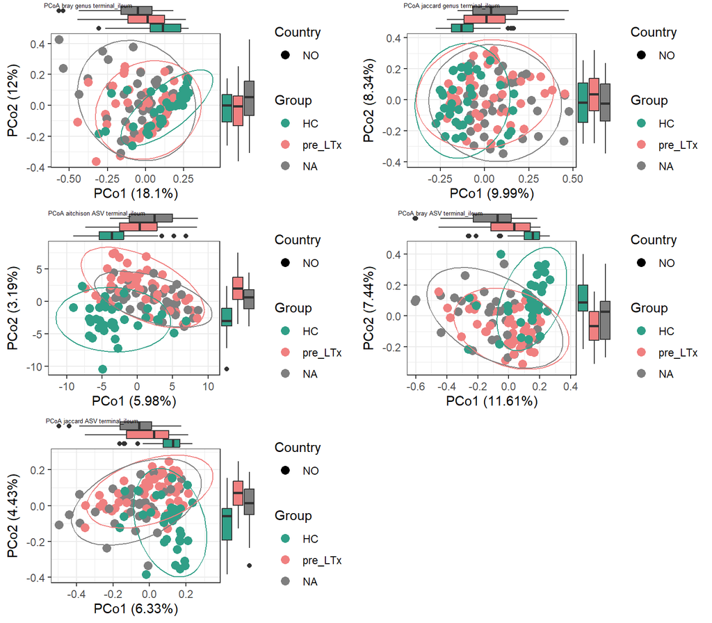

```r
ggarrange(plotlist = supplements_beta[grepl("PCoA",names(supplements_beta))],
          labels=names(supplements_beta[grepl("PCoA",names(supplements_beta))]),
          font.label = list(size=5,face="plain"),
          ncol=2,nrow=3)
```

#### Univariate analysis

**Number of significant taxa**

```r
knitr::kable(cbind(as.data.frame(lapply(list_intersections,nrow)),
      as.data.frame(lapply(psc_effect,nrow))) %>% t() %>%
  `colnames<-`("Count") %>%
  `rownames<-`(c(names(list_intersections),"PSC effect ASV","PSC effect Genus","PSC effect Phylum")),caption="Number of significant taxa")
```

Number of significant taxa

|  | Count |
| --- | --- |
| terminal_ileum genus healthy vs pre_ltx | 44 |
| terminal_ileum genus pre_ltx vs post_ltx | 11 |
| terminal_ileum genus healthy vs post_ltx | 31 |
| terminal_ileum ASV healthy vs pre_ltx | 40 |
| terminal_ileum ASV pre_ltx vs post_ltx | 8 |
| terminal_ileum ASV healthy vs post_ltx | 31 |
| terminal_ileum phylum healthy vs pre_ltx | 2 |
| terminal_ileum phylum pre_ltx vs post_ltx | 0 |
| terminal_ileum phylum healthy vs post_ltx | 2 |
| PSC effect ASV | 21 |
| PSC effect Genus | 12 |
| PSC effect Phylum | 2 |

#### Machine learning

**Main models**

Summary

```r
knitr::kable(models_summ_df_ileum %>% dplyr::select(
"alpha","lambda",
"auc_optimism_corrected",
"auc_optimism_corrected_CIL",
"auc_optimism_corrected_CIU"),
             digits=2,caption="Elastic net results")
```

Elastic net results

|  | alpha | lambda | auc_optimism_corrected | auc_optimism_corrected_CIL | auc_optimism_corrected_CIU |
| --- | --- | --- | --- | --- | --- |
| pre_ltx vs healthy ASV terminal_ileum | 0.2 | 0.08 | 0.94 | 0.91 | 0.97 |
| pre_ltx vs post_ltx ASV terminal_ileum | 0.4 | 0.05 | 0.95 | 0.91 | 0.98 |
| post_ltx vs healthy ASV terminal_ileum | 0.2 | 0.04 | 0.94 | 0.80 | 1.00 |
| pre_ltx vs healthy genus terminal_ileum | 0.4 | 0.02 | 0.95 | 0.87 | 0.99 |
| pre_ltx vs post_ltx genus terminal_ileum | 1.0 | 0.05 | 0.97 | 0.90 | 1.00 |
| post_ltx vs healthy genus terminal_ileum | 0.2 | 0.19 | 0.92 | 0.79 | 0.99 |

**ROC - ASV level**

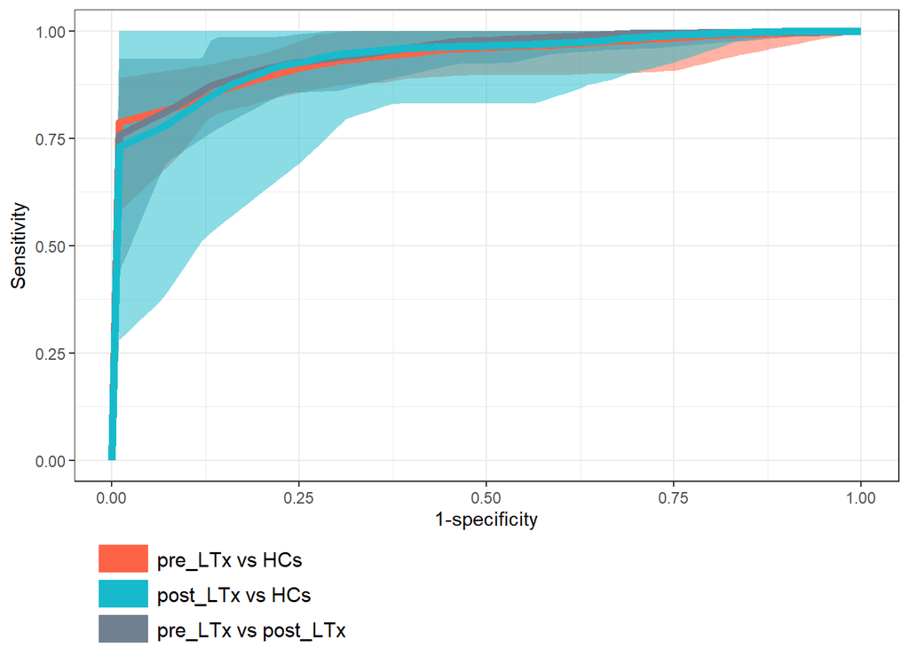

```r
roc_curve_all_custom(roc_cs[c(1:3)],
                     Q="Q1_norway",
                     model_name="enet_model")
```

**ROC - Genus level**

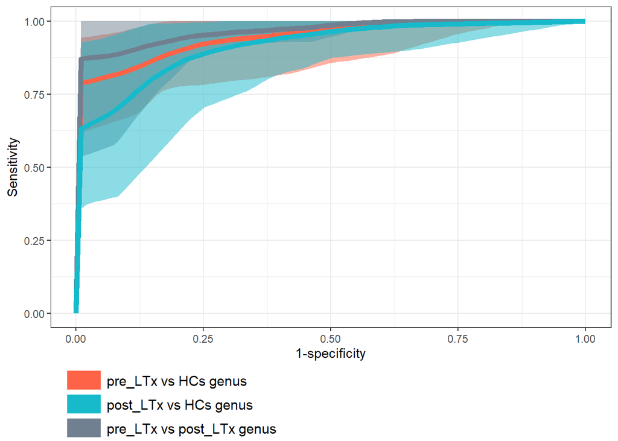

```r
roc_curve_all_custom(roc_cs[c(4:6)],Q="Q1_norway",
                     model_name="enet_model")
```

**Supplementary models**

Summary

```r
# Build final dataframe
models_list[["enet_model"]] <- models_summ_df_ileum
final_df <- tibble(row_names = rownames(models_list[[1]]))

# Loop through models and extract required values
for (model_name in names(models_list)) {
  model_df <- models_list[[model_name]]

  # Combine AUC_optimism_corrected with its CI values
  final_df[[model_name]] <- paste0(
    round(model_df$auc_optimism_corrected, 3),
    " (", round(model_df$auc_optimism_corrected_CIL, 3), "; ",
    round(model_df$auc_optimism_corrected_CIU, 3), ")"
  )
}

knitr::kable(final_df, caption="All models")
```

All models

| row_names | knn_model | rf_model | gbm_model | enet_model_ra | knn_model_ra | rf_model_ra | gbm_model_ra | enet_model |
| --- | --- | --- | --- | --- | --- | --- | --- | --- |
| pre_ltx vs healthy ASV terminal_ileum | 0.869 (0.781; 0.922) | 0.946 (0.829; 0.994) | 0.927 (0.858; 0.995) | 0.884 (0.77; 0.97) | 0.892 (0.821; 0.942) | 0.985 (0.955; 1) | 0.944 (0.884; 0.997) | 0.939 (0.907; 0.969) |
| pre_ltx vs post_ltx ASV terminal_ileum | 0.773 (0.675; 0.879) | 0.941 (0.89; 0.99) | 0.927 (0.858; 0.995) | 0.775 (0.569; 0.891) | 0.596 (0.51; 0.731) | 0.964 (0.919; 0.996) | 0.944 (0.884; 0.997) | 0.949 (0.906; 0.979) |
| post_ltx vs healthy ASV terminal_ileum | 0.898 (0.779; 0.997) | 0.926 (0.855; 1) | 0.927 (0.858; 0.995) | 0.879 (0.772; 0.995) | 0.869 (0.781; 0.941) | 0.906 (0.795; 0.999) | 0.944 (0.884; 0.997) | 0.941 (0.799; 1) |
| pre_ltx vs healthy genus terminal_ileum | 0.892 (0.745; 0.964) | 0.958 (0.854; 0.995) | 0.927 (0.858; 0.995) | 0.901 (0.812; 0.99) | 0.838 (0.705; 0.939) | 0.965 (0.852; 1) | 0.944 (0.884; 0.997) | 0.945 (0.868; 0.994) |
| pre_ltx vs post_ltx genus terminal_ileum | 0.76 (0.655; 0.92) | 0.93 (0.9; 0.956) | 0.927 (0.858; 0.995) | 0.647 (0.493; 0.836) | 0.565 (0.426; 0.712) | 0.974 (0.943; 1) | 0.944 (0.884; 0.997) | 0.969 (0.905; 1) |
| post_ltx vs healthy genus terminal_ileum | 0.913 (0.857; 0.988) | 0.927 (0.858; 0.995) | 0.927 (0.858; 0.995) | 0.9 (0.809; 0.986) | 0.818 (0.746; 0.9) | 0.944 (0.884; 0.997) | 0.944 (0.884; 0.997) | 0.918 (0.789; 0.992) |

ROC - ASV

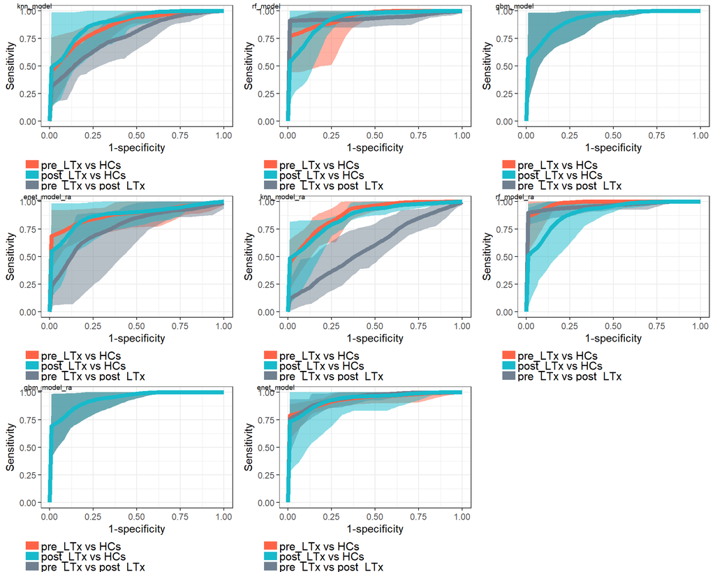

```r
rocs_list <- supplements_models$roc_cs
rocs_list[["enet_model"]] <- roc_cs

plot_list <- list()

for (model_name in names(rocs_list)) {
  plot_list[[model_name]] <- roc_curve_all_custom(rocs_list[[model_name]][c(1:3)],
                       Q="Q1_norway",
                       model_name=model_name)
}

ggarrange(plotlist = plot_list,labels = names(rocs_list),font.label = list(face="plain",size=7))
```

ROC - genus

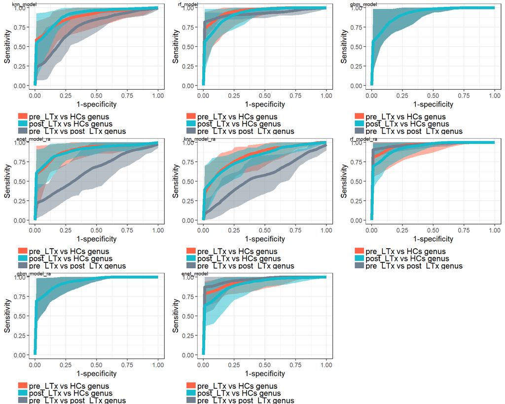

```r
plot_list <- list()

for (model_name in names(rocs_list)) {
  plot_list[[model_name]] <- roc_curve_all_custom(rocs_list[[model_name]][c(4:6)],
                       Q="Q1_norway",
                       model_name=model_name)
}

ggarrange(plotlist = plot_list,labels = names(rocs_list),font.label = list(face="plain",size=7))
```